# Algebra

# Thursday September 5th

## Rings

Recall the definition of a ring: A *ring* $(R, +, \times)$ is a set with binary operations such that

1. $(R, +)$ is a group,
2. $(R, \times)$ is a monoid.

*Examples:* $R = {\mathbb{Z}}, {\mathbb{Q}}, {\mathbb{R}}, {\mathbb{C}}$, or the ring of $n\times n$ matrices, or ${\mathbb{Z}}_n$.

A ring is *commutative* iff $ab = ba$ for every $a,b\in R$, and *a ring with unity* is a ring such that $\exists 1 \in R$ such that $a1 = 1a = a$.

*Exercise*: Show that $1$ is unique if it exists.

In a ring with unity, an element $a\in R$ is a *unit* iff $\exists b\in R$ such that $ab = ba = 1$.

**Definition:** A ring with unity is a **division ring** $\iff$ every nonzero element is a unit.

**Definition:** A division ring is a *field* $\iff$ it is commutative.

**Definition:** Suppose that $a,b \neq 0$ with $ab = 0$. Then $a,b$ are said to be *zero divisors*.

**Definition:** A commutative ring without zero divisors is an *integral domain*.

*Example:* In ${\mathbb{Z}}_n$, an element $a$ is a zero divisor iff $\gcd(a, n) \neq 1$.

*Fact:* In a ring with no zero divisors, we have
$$\begin{align*} ab = ac \text{ and } a\neq 0 \implies b=c .\end{align*}$$

**Theorem:** Every field is an integral domain.

*Proof:* Let $R$ be a field. If $ab=0$ and $a\neq 0$, then $a^{-1}$ exists and so $b=0$.

$\hfill\blacksquare$

**Theorem:** Any finite integral domain is a field.

*Proof:*

> Idea: Similar to the pigeonhole principle.

Let $D = \left\{{0, 1, a_1, \cdots, a_n}\right\}$ be an integral domain. Let $a_j \neq 0, 1$ be arbitrary, and consider $a_j D = \left\{{a_j x \mathrel{\Big|}x\in D\setminus\left\{{0}\right\}}\right\}$.

Then $a_j D = D\setminus\left\{{0}\right\}$ as sets. But
$$\begin{align*} a_j D = \left\{{a_j, a_j a_1, a_j a_2, \cdots, a_j a_n}\right\}. \end{align*}$$

Since there are no zero divisors, $0$ does not occur among these elements, so some $a_j a_k$ must be equal to 1.

$\hfill\blacksquare$

## Field Extensions

If $F \leq E$ are fields, then $E$ is a vector space over $F$, for which the dimension turns out to be important.

**Definition**: We can consider
$$\begin{align*} \operatorname{Aut}(E/F) \mathrel{\vcenter{:}}=\left\{{\sigma: E {\circlearrowleft}\mathrel{\Big|}f\in F \implies \sigma(f) = f}\right\}, \end{align*}$$
i.e. the field automorphisms of $E$ that fix $F$.

*Examples of field extensions:* ${\mathbb{C}}\to {\mathbb{R}}\to {\mathbb{Q}}$.

Let $F[x]$ the polynomials with coefficients in $F$.

**Theorem:** Let $F$ be a field and $f(x) \in F[x]$ be a non-constant polynomial. Then there exists an $F \to E$ and some $\alpha \in E$ such that $f(\alpha) = 0$.

*Proof:* Since $F[x]$ is a unique factorization domain, given $f(x)$ we can find an irreducible $p(x)$ such that $f(x) = p(x) g(x)$ for some $g(x)$. So consider $E = F[x] / (p)$.

Since $p$ is irreducible, $(p)$ is a prime ideal, but in $F[x]$ prime ideals are maximal and so $E$ is a field.

Then define
$$\begin{align*} \psi: F &\to E \\ a &\mapsto a + (p) .\end{align*}$$

Then $\psi$ is a homomorphism of rings: supposing $\psi(\alpha) = 0$, we must have $\alpha \in (p)$. But all such elements are multiples of a polynomial of degree $d \geq 1$, and $\alpha$ is a scalar, so this can only happen if $\alpha = 0$.

Then consider $\alpha = x + (p)$; the claim is that $p(\alpha) = 0$ and thus $f(\alpha) = 0$. We can compute

$$\begin{align*} p(x + (p)) &= a_0 + a_1(x + (p)) + \cdots + a_n(x + (p))^n \\ &= p(x) + (p) = 0 .\end{align*}$$

$\hfill\blacksquare$

*Example:* ${\mathbb{R}}[x] / (x^2 + 1)$ over ${\mathbb{R}}$ is isomorphic to ${\mathbb{C}}$ as a field.

## Algebraic and Transcendental Elements

**Definition:** An element $\alpha \in E$ with $F \to E$ is **algebraic** over $F$ iff there is a nonzero polynomial in $f \in F[x]$ such that $f(\alpha) = 0$.

Otherwise, $\alpha$ is said to be **transcendental**.

*Examples:*

- $\sqrt 2 \in {\mathbb{R}}\leftarrow{\mathbb{Q}}$ is algebraic, since it satisfies $x^2 - 2$.
- $\sqrt{-1} \in {\mathbb{C}}\leftarrow{\mathbb{Q}}$ is algebraic, since it satisfies $x^2 + 1$.
- $\pi, e \in {\mathbb{R}}\leftarrow{\mathbb{Q}}$ are transcendental

  > This takes some work to show.

An *algebraic number* $\alpha \in {\mathbb{C}}$ is an element that is algebraic over ${\mathbb{Q}}$.

*Fact:* The set of algebraic numbers forms a field.

**Definition:** Let $F \leq E$ be a field extension and $\alpha \in E$. Define a map

$$\begin{align*} \phi_\alpha: F[x] &\to E \\ \phi_\alpha(f) &= f(\alpha) .\end{align*}$$

This is a homomorphism of rings and referred to as the *evaluation homomorphism*.

**Theorem:** Then $\phi_\alpha$ is injective iff $\alpha$ is transcendental.

> Note: otherwise, this map will have a kernel, which will be generated by a single element that is referred to as the **minimal polynomial** of $\alpha$.

## Minimal Polynomials

**Theorem:** Let $F\leq E$ be a field extension and $\alpha \in E$ algebraic over $F$. Then

1. There exists a polynomial $p\in F[x]$ of minimal degree such that $p(\alpha) = 0$.
2. $p$ is irreducible.
3. $p$ is unique up to a constant.

*Proof:*

Since $\alpha$ is algebraic, $f(\alpha) = 0$. So write $f$ in terms of its irreducible factors, so $f(x) = \prod p_j(x)$ with each $p_j$ irreducible. Then $p_i(\alpha) = 0$ for some $i$ because we are in a field and thus don’t have zero divisors.

So there exists at least one $p_i(x)$ such that $p(\alpha) = 0$, so let $q$ be one such polynomial of minimal degree.

Suppose that $\deg q < \deg p_i$. Using the Euclidean algorithm, we can write $p(x) = q(x) c(x) + r(x)$ for some $c$, and some $r$ where $\deg r < \deg q$.

But then $0 = p(\alpha) = q(\alpha)c(\alpha) + r(\alpha)$, but if $q(\alpha) = 0$, then $r(\alpha) = 0$. So $r(x)$ is identically zero, and so $p(x) - q(x) = c(x) = c$, a constant.

$\hfill\blacksquare$

**Definition:** Let $\alpha \in E$ be algebraic over $F$, then the unique monic polynomial $p\in F[x]$ of minimal degree such that $p(\alpha) = 0$ is the **minimal polynomial** of $\alpha$.

# Tuesday September 10th

## Vector Spaces

**Definition:** Let ${\mathbb{F}}$ be a field. A **vector space** is an abelian group $V$ with a map ${\mathbb{F}}\times V \to V$ such that

- $\alpha(\beta \mathbf{v}) = (\alpha \beta) \mathbf{v}$
- $(\alpha + \beta)\mathbf{v} = \alpha \mathbf{v} + \beta \mathbf{v}$,
- $\alpha(\mathbf{v} + \mathbf{w}) = \alpha \mathbf{v} + \alpha \mathbf{w}$
- $1\mathbf{v} = \mathbf{v}$

*Examples:* ${\mathbb{R}}^n, {\mathbb{C}}^n , F[x] = \mathrm{span}(\left\{{1, x, x^2, \cdots}\right\}), L^2({\mathbb{R}})$

**Definition:** Let $V$ be a vector space over ${\mathbb{F}}$; then a set $W \subseteq V$ *spans* $V$ iff for every $\mathbf{v}\in V$, one can write $\mathbf{v} = \sum \alpha_i \mathbf{w}_i$ where $\alpha_i \in {\mathbb{F}},~\mathbf{w}_i \in W$.

**Definition:** $V$ is *finite dimensional* if there exists a finite spanning set.

**Definition:** A set $W \subseteq V$ is *linearly independent* iff
$$\begin{align*} \sum \alpha_i \mathbf{w}_i = \mathbf{0} \implies \alpha_i = 0 \text{ for all } i .\end{align*}$$

**Definition:** A *basis* for $V$ is a set $W \subseteq V$ such that

1. $W$ is linearly independent, and
2. $W$ spans $V$.

A basis is a midpoint between a spanning set and a linearly independent set.

We can add vectors to a set until it is spanning, and we can throw out vectors until the remaining set is linearly independent. This is encapsulated in the following theorems:

**Theorem:** If $W$ spans $V$, then some subset of $W$ spans $V$.

**Theorem:** If $W$ is a set of linearly independent vectors, then some superset of $W$ is a basis for $V$.

*Fact:* Any finite-dimensional vector spaces has a finite basis.

**Corollary:** Any two bases have the same number of elements.

> So we define the dimension of $V$ to be the number of elements in any basis, which is a unique number.

## Algebraic Extensions

**Definition:** $E \geq F$ is an algebraic extension iff every $\alpha \in E$ is algebraic of $F$.

**Definition:** $E \geq F$ is a *finite extension* iff $E$ is finite-dimensional as an $F{\hbox{-}}$vector space.

*Notation:* $[E: F] = \dim_F E$, the dimension of $E$ as an $F{\hbox{-}}$vector space.

*Observation:* If $E = F(\alpha)$ where $\alpha$ is algebraic over $F$, then $E$ is an algebraic extension of $F$.

*Observation:* If $E\geq F$ and $[E: F] = 1$, then $E=F$.

**Theorem:** If $E \geq F$ is a finite extension, then $E$ is algebraic over $F$.

*Proof:* Let $\beta \in E$. Then the set $\left\{{1, \beta, \beta^2, \cdots}\right\}$ is not linearly independent. So $\sum_{i=0}^n c_i \beta^i = 0$ for some $n$ and some $c_i$. But then $\beta$ is algebraic. $\hfill\blacksquare$

> Note that the converse is not true in general. *Example*: Let $E = \overline {\mathbb{R}}$ be the algebraic numbers. Then $E \geq {\mathbb{Q}}$ is algebraic, but $[E : {\mathbb{Q}}] = \infty$.

**Theorem:** Let $K \geq E \geq F$, then $[K: F] = [K: E] [E: F]$.

*Proof:* Let $\left\{{\alpha_i}\right\}^m$ be a basis for $E/F$ Let $\left\{{\beta_i}\right\}^n$ be a basis for $K / E$. Then the RHS is $mn$.

*Claim:* $\left\{{\alpha_i \beta_j}\right\}^{m, n}$ is a basis for $K/ F$.

*Linear independence:*

$$\begin{align*} \sum_{i, j} c_{ij} \alpha _i \beta_j &= 0 \\ \implies \sum_j \sum_i c_{ij} \alpha_i \beta_j &= 0 \\ \implies \sum_i c_{ij} \alpha_i &= 0 \quad \text{since $\beta$ form a basis} \\ \implies \sum c_{ij} &= 0 \quad \text{since $\alpha$ form a basis} .\end{align*}$$

*Exercise*: Show this is also a spanning set.

$\hfill\blacksquare$

**Corollary:** Let $E_r \geq E_{r-1} \geq \cdots \geq E_1 \geq F$, then
$$\begin{align*} [E_r: F]= [E_r: E_{r-1}][E_{r-1}:E_{r-2}] \cdots [E_2: E_1][E_1 : F] .\end{align*}$$

*Observation:* If $\alpha \in E \geq F$ and $\alpha$ is algebraic over $F$ where $E \geq F(\alpha) \geq F$, then $F(\alpha)$ is algebraic (since $[F(\alpha): F] < \infty$) and $[F(\alpha): F]$ is the degree of the minimal polynomial of $\alpha$ over $F$.

**Corollary:** Let $E = F(\alpha) \geq F$ where $\alpha$ is algebraic. Then
$$\begin{align*}\beta \in F(\alpha) \implies \deg \min(\beta, F) {~\Bigm|~}\deg \min(\alpha, F) .\end{align*}$$

*Proof:* Since $F(\alpha) \geq F(\beta) \geq F$, we have $[F(\alpha): F] = [F(\alpha): F(\beta)][F(\beta): F]$. But just note that
$$\begin{align*} [F(\alpha): F] &= \deg \min (\alpha, F) \text{ and } \\ [F(\beta): F] &= \deg \min (\beta, F) .\end{align*}$$

$\hfill\blacksquare$

**Theorem:** Let $E \geq F$ be algebraic, then
$$\begin{align*} [E: F] < \infty \iff E = F(\alpha_1, \cdots, \alpha_n) \text{ for some } \alpha_n \in E .\end{align*}$$

## Algebraic Closures

**Definition:** Let $E \geq F$, and define
$$\begin{align*} \overline{F_E} = \left\{{\alpha \in E \mathrel{\Big|}\alpha \text{ is algebraic over } F}\right\} \end{align*}$$
to be the **algebraic closure of $F$ in $E$**.

*Example:* ${\mathbb{Q}}\hookrightarrow{\mathbb{C}}$, while $\overline {\mathbb{Q}}= \Bbb{A}$ is the field of algebraic numbers, which is a dense subfield of ${\mathbb{C}}$.

**Proposition:** $\overline{F_E}$ is a always field.

*Proof:* Let $\alpha, \beta \in \overline{F_E}$, so $[F(\alpha, \beta): F] < \infty$. Then $F(\alpha, \beta) \subseteq \overline{F_E}$ is algebraic over $F$ and
$$\begin{align*} \alpha\pm \beta, \quad \alpha\beta,\quad \frac \alpha \beta \quad \in F(\alpha, \beta) .\end{align*}$$

So $\overline{F_E}$ is a subfield of $E$ and thus a field.

**Definition:** A field $F$ is **algebraically closed** iff every non-constant polynomial in $F[x]$ is a root in $F$. Equivalently, every polynomial in $F[x]$ can be factored into linear factors.

If $F$ is algebraically closed and $E\geq F$ and $E$ is algebraic, then $E=F$.

### The Fundamental Theorem of Algebra

**Theorem (Fundamental Theorem of Algebra):** ${\mathbb{C}}$ is an algebraically closed field.

*Proof:*

**Liouville’s theorem**: A bounded entire function $f: {\mathbb{C}}{\circlearrowleft}$ is constant.

- *Bounded* means $\exists M {~\mathrel{\Big|}~}z\in {\mathbb{C}}\implies {\left\lvert {f(z)} \right\rvert} \leq M$.
- *Entire* means analytic everywhere.

Let $f(z) \in {\mathbb{C}}[z]$ be a polynomial without a zero which is non-constant.

Then $\frac 1 {f(z)}: {\mathbb{C}}{\circlearrowleft}$ is analytic and bounded, and thus constant, and contradiction.

$\hfill\blacksquare$

## Geometric Constructions:

Given the tools of a straightedge and compass, what real numbers can be constructed? Let $\mathcal C$ be the set of such numbers.

**Theorem:** $C$ is a subfield of ${\mathbb{R}}$.

# Thursday September 12th

## Geometric Constructions

**Definition:** A real number $\alpha$ is said to be **constructible** iff ${\left\lvert {\alpha} \right\rvert}$ is constructible using a ruler and compass. Let $\mathcal C$ be the set of constructible numbers.

Note that $\pm 1$ is constructible, and thus so is ${\mathbb{Z}}$.

**Theorem:** $\mathcal{C}$ is a field.

*Proof:* It suffices to construct $\alpha \pm \beta,~~ \alpha\beta,~~ \alpha / \beta$.

*Showing $\pm$ and inverses:* Relatively easy.

*Showing closure under products:*

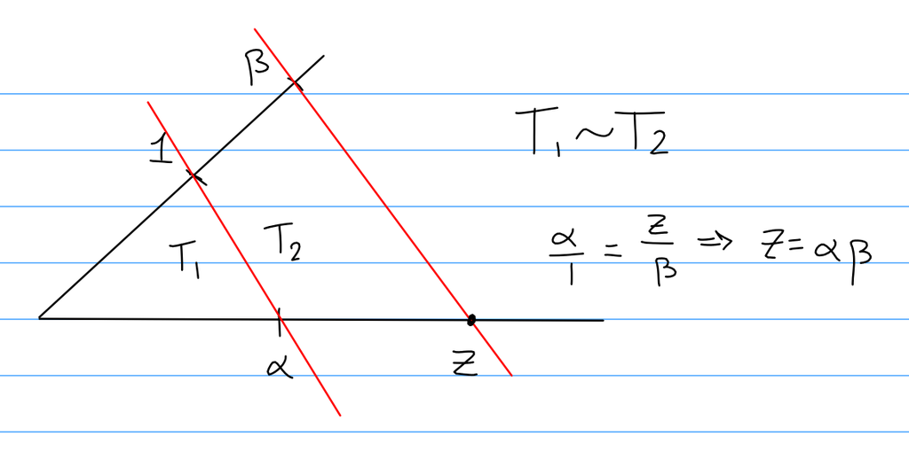

**Corollary:** ${\mathbb{Q}}\leq \mathcal C$ is a subfield.

Can we get all of ${\mathbb{R}}$ with $\mathcal C$? The operations we have are

1. Intersect 2 lines (gives nothing new)
2. Intersect a line and a circle
3. Intersect 2 circles

Operation (3) reduces to (2) by subtracting two equations of a circle ($x^2 + y^2 + ax + by + c$) to get an equation of a line.

Operation (2) reduces to solving quadratic equations.

**Theorem:** $\mathcal C$ contains precisely the real numbers obtained by adjoining finitely many square roots of elements in ${\mathbb{Q}}$.

*Proof:* Need to show that $\alpha \in \mathcal C \implies \sqrt \alpha \in \mathcal C$.

$\hfill\blacksquare$

*Corollary:* Let $\gamma \in \mathcal{C}$ be constructible. Then there exist $\left\{{\alpha_i}\right\}_{i=1}^n$ such that
$$\begin{align*} \gamma = \prod_{i=1}^n \alpha_i \quad\text{and}\quad [{\mathbb{Q}}(\alpha_1, \cdots, \alpha_j): {\mathbb{Q}}(\alpha_1, \cdots, \alpha_{j-1})] = 2 ,\end{align*}$$
and $[{\mathbb{Q}}(\alpha): {\mathbb{Q}}] = 2^d$ for some $d$.

**Applications:**

**Doubling the cube:** Given a cube of size 1, can we construct one of size 2? To do this, we’d need $x^3 = 2$. But note that $\min(\sqrt[3]{2}, {\mathbb{Q}}) = x^3 - 2 = f(x)$ is irreducible over ${\mathbb{Q}}$. So $[{\mathbb{Q}}(\sqrt[3]{2}): {\mathbb{Q}}] = 3 \neq 2^d$ for any $d$, so this can not be constructible.

**Trisections of angles:** We want to construct regular polygons, so we’ll need to construct angles. We can get some by bisecting known angles, but can we get all of them?

*Example:* Attempt to construct $20^\circ$ by trisecting the known angle $60^\circ$, which is constructible using a triangle of side lengths $1,2,\sqrt 3$.

If $20^\circ$ were constructible, $\cos 20^\circ$ would be as well. There is an identity
$$\begin{align*} \cos 3\theta = 4\cos^3 \theta - 3\cos \theta .\end{align*}$$

Letting $\theta = 20^\circ$ so $3\theta = 60^\circ$, we obtain
$$\begin{align*} \frac 1 2 = 4(\cos 20^\circ)^3 - 3\cos 20^\circ, \end{align*}$$

so if we let $x = \cos 20^\circ$ then $x$ satisfies the polynomial $f(x) = 8x^3 - 6x - 1$, which is irreducible. But then $[{\mathbb{Q}}(20^\circ):{\mathbb{Q}}] = 3 \neq 2^d$, so $\cos 20^\circ \not\in\mathcal C$.

## Finite Fields

**Definition:** The *characteristic* of $F$ is the smallest $n\geq 0$ such that $n1 = 0$, or $0$ if such an $n$ does not exist.

*Exercise*: For a field $F$, show that $\operatorname{char}~F = 0$ or $p$ a prime.

Note that if $\operatorname{char}~F = 0$, then ${\mathbb{Z}}\in F$ since $1,~ 1+1,~ 1+1+1, \cdots$ are all in $F$. Since inverses must also exist in $F$, we must have ${\mathbb{Q}}\in F$ as well. So $\operatorname{char}~F = 0 \iff F$ is infinite.

If $\operatorname{char}~F = p$, it follows that ${\mathbb{Z}}_p \subset F$.

**Theorem:**
$$\begin{align*} \text{For } E \geq F \text{ where } [E: F] = n \text{ and } F \text{ finite }, \quad {\left\lvert {F} \right\rvert} = q \implies {\left\lvert {E} \right\rvert} = q^n .\end{align*}$$

*Proof:* $E$ is a vector space over $F$. Let $\left\{{v_i}\right\}^n$ be a basis. Then $\alpha \in E \implies \alpha = \sum_{i=1}^n a_i v_i$ where each $a_i \in F$. There are $q$ choices for each $a_i$, and $n$ coefficients, yielding $q^n$ distinct elements.

$\hfill\blacksquare$

**Corollary:** Let $E$ be a finite field where $\operatorname{char}~E = p$. Then ${\left\lvert {E} \right\rvert} = p^n$ for some $n$.

**Theorem:** Let ${\mathbb{Z}}_p \leq E$ with ${\left\lvert {E} \right\rvert} = p^n$. If $\alpha \in E$, then $\alpha$ satisfies
$$\begin{align*} x^{p^n} - x \in {\mathbb{Z}}_p[x]. \end{align*}$$

*Proof:* If $\alpha = 0$, we’re done. So suppose $\alpha \neq 0$, then $\alpha \in E^{\times}$, which is a group of order $p^n - 1$. So $\alpha^{p^n - 1} = 1$, and thus $\alpha \alpha^{p^n - 1} = \alpha 1 \implies \alpha^{p^n} = \alpha$.

$\hfill\blacksquare$

**Definition:** $\alpha \in F$ is an *$n$th root of unity* iff $\alpha^n = 1$. It is a *primitive* root of unity of $n$ iff $k\leq n \implies \alpha^k \neq 1$ (so $n$ is the smallest power for which this holds).

**Fact:** If $F$ is a finite field, then $F^{\times}$ is a cyclic group.

**Corollary:** If $E \geq F$ with $[E: F] = n$, then $E = F(\alpha)$ for just a single element $\alpha$.

*Proof:* Choose $\alpha \in E^{\times}$ such that $\left\langle{\alpha }\right\rangle= E^{\times}$. Then $E = F(\alpha)$.

$\hfill\blacksquare$

Next time: Showing the existence of a field with $p^n$ elements.

For now: derivatives.

Let $f(x) \in F[x]$ by a polynomial with a multiple zero $\alpha \in E$ for some $E \geq F$.

If it has multiplicity $m \geq 2$, then note that
$$\begin{align*} f(x) = (x-\alpha)^m g(x) \implies f'(x) m(x-\alpha)^{m-1}g(x) + g'(x)(x-\alpha)^m \implies f'(\alpha) = 0. \end{align*}$$
So
$$\begin{align*} \alpha \text{ a multiple zero of } f \implies f'(\alpha) = 0 .\end{align*}$$

The converse is also useful.

*Application:* Let $f(x) = x^{p^n} - x$, then $f'(x) = p^n x^{p^n - 1} - 1 = -1 \neq 0$, so all of the roots are distinct.

# Tuesday September 17th

## Finite Fields and Roots of Polynomials

*Recall from last time:*

Let ${\mathbb{F}}$ be a finite field. Then ${\mathbb{F}}^{\times}= {\mathbb{F}}\setminus\left\{{0}\right\}$ is *cyclic* (this requires some proof).

Let $f \in {\mathbb{F}}[x]$ with $f(\alpha) = 0$. Then $\alpha$ is a *multiple root* if $f'(\alpha) = 0$.

**Lemma:** Let ${\mathbb{F}}$ be a finite field with characteristic $p > 0$. Then
$$\begin{align*} f(x) = x^{p^n} - x \in {\mathbb{F}}[x] \end{align*}$$

has $p^n$ distinct roots.

*Proof:*
$$\begin{align*} f'(x) = p^n x^{p^n-1}-1 = -1 ,\end{align*}$$
since we are in char $p$.

This is identically -1, so $f'(x) \neq 0$ for any $x$. So there are no multiple roots. Since there are at most $p^n$ roots, this gives exactly $p^n$ distinct roots.

$\hfill\blacksquare$

**Theorem:** A field with $p^n$ elements exists (denoted $\mathbb{GF}(p^n)$) for every prime $p$ and every $n > 0$.

*Proof:* Consider ${\mathbb{Z}}_p \subseteq K \subseteq \overline{{\mathbb{Z}}}_p$ where $K$ is the set of zeros of $x^{p^n}-x$. Then we claim $K$ is a field.

Suppose $\alpha, \beta \in K$. Then $(\alpha \pm \beta)^{p^n} = \alpha^{p^n} \pm \beta^{p^n}$.

We also have
$$\begin{align*} (\alpha\beta)^{p^n} = \alpha^{p^n}\beta^{p^n} - \alpha\beta \text{ and } \alpha^{-p^n} = \alpha^{-1} .\end{align*}$$

So $K$ is a field and ${\left\lvert {K} \right\rvert} = p^n$.

$\hfill\blacksquare$

**Corollary:** Let $F$ be a finite field. If $n\in{\mathbb{N}}^+$, then there exists an $f(x) \in F[x]$ that is irreducible of degree $n$.

*Proof:* Let $F$ be a finite field, so ${\left\lvert {F} \right\rvert} = p^r$. By the previous lemma, there exists a $K$ such that ${\mathbb{Z}}_p \subseteq k \subseteq \overline F$.

$K$ is defined as
$$\begin{align*} K \mathrel{\vcenter{:}}=\left\{{\alpha \in F \mathrel{\Big|}\alpha^{p^n} - \alpha = 0}\right\} .\end{align*}$$

We also have
$$\begin{align*} F = \left\{{\alpha \in \overline F {~\mathrel{\Big|}~}\alpha^{p^n} - \alpha = 0}\right\}.\end{align*}$$

Moreover, $p^{rs} = p^r p^{r(s-1)}$. So let $\alpha \in F$, then $\alpha^{p^r} - \alpha = 0$.

Then
$$\begin{align*} \alpha^{p^{rn}} = \alpha^{p^r p^{r(n-1)}} = (\alpha^{p^r})^{p^{r(n-1)}} = \alpha^{p^{r(n-1)}} ,\end{align*}$$

and we can continue reducing this way to show that this is yields to $\alpha^{p^r} = \alpha$.

So $\alpha \in K$, and thus $F \leq K$. We have $[K:F] = n$ by counting elements. Now $K$ is simple, because $K^{\times}$ is cyclic. Let $\beta$ be the generator, then $K = F(\beta)$. This the minimal polynomial of $\beta$ in $F$ has degree $n$, so take this to be the desired $f(x)$.

$\hfill\blacksquare$

## Simple Extensions

Let $F \leq E$ and
$$\begin{align*} \phi_\alpha: F[x] &\to E \\ f &\mapsto f(\alpha) .\end{align*}$$

denote the evaluation map.

**Case 1:** Suppose $\alpha$ is **algebraic** over $F$.

There is a kernel for this map, and since $F[x]$ is a PID, this ideal is generated by a single element – namely, the minimal polynomial of $\alpha$.

Thus (applying the first isomorphism theorem), we have $F(\alpha) \supseteq E$ isomorphic to $F[x] / \min(\alpha, F)$. Moreover, $F(\alpha)$ is the smallest subfield of $E$ containing $F$ and $\alpha$.

**Case 2:** Suppose $\alpha$ is **transcendental** over $F$.

Then $\ker \phi_\alpha = 0$, so $F[x] \hookrightarrow E$. Thus $F[x] \cong F[\alpha]$.

**Definition:** $E \geq F$ is a *simple extension* if $E = F(\alpha)$ for some $\alpha \in E$.

**Theorem:** Let $E = F(\alpha)$ be a simple extension of $F$ where $\alpha$ is algebraic over $F$.

Then every $\beta \in E$ can be uniquely expressed as
$$\begin{align*} \beta = \sum_{i=0}^{n-1} c_i \alpha^i \text{ where } n = \deg \min(\alpha, F) .\end{align*}$$

*Proof:*

*Existence:* We have
$$\begin{align*} F(\alpha) = \left\{{\sum_{i=1}^r \beta_i \alpha^i {~\mathrel{\Big|}~}\beta_i \in F}\right\} ,\end{align*}$$
so all elements look like polynomials in $\alpha$.

Using the minimal polynomial, we can reduce the degree of any such element by rewriting $\alpha^n$ in terms of lower degree terms:

$$\begin{align*} f(x) = \sum_{i=0}^n a_i x^i, \quad f(\alpha) &= 0 \\ \implies \sum_{i=0}^n a_i \alpha^i &= 0 \\ \implies \alpha^n &= -\sum_{i=0}^{n-1} a_i \alpha^i .\end{align*}$$

*Uniqueness:* Suppose $\sum c_i \alpha^i = \sum^{n-1} d_i \alpha^i$. Then $\sum^{n-1} (c_i - d_i) \alpha^i = 0$. But by minimality of the minimal polynomial, this forces $c_i - d_i = 0$ for all $i$.

$\hfill\blacksquare$

> Note: if $\alpha$ is algebraic over $F$, then $\left\{{1, \alpha, \cdots \alpha^{n-1}}\right\}$ is a basis for $F(\alpha)$ over $F$ where $n = \deg \min(\alpha, F)$. Moreover,
> $$\begin{align*} [F(\alpha):F] = \dim_F F(\alpha) = \deg\min(\alpha, F) .\end{align*}$$

> Note: adjoining any root of a minimal polynomial will yield isomorphic (usually not *identical*) fields. These are distinguished as subfields of the algebraic closure of the base field.

**Theorem:** Let $F \leq E$ with $\alpha \in E$ algebraic over $F$.

If $\deg\min(\alpha, F) = n$, then $F(\alpha)$ has dimension $n$ over $F$, and $\left\{{1, \alpha, \cdots, \alpha^{n-1}}\right\}$ is a basis for $F(\alpha)$ over $F$.

Moreover, any $\beta \in F(\alpha)$, is *also* algebraic over $F$,and $\deg\min(\beta, F) {~\Bigm|~}\deg \min(\alpha, F)$.

*Proof of first part:* Exercise.

*Proof of second part:* We want to show that $\beta$ is algebraic over $F$.

We have
$$\begin{align*} [F(\alpha):F] = [F(\alpha): F(\beta)][F(\beta): F] ,\end{align*}$$
so $[F(\beta) : F]$ is less than $n$ since this is a finite extension, and the division of degrees falls out immediately.

$\hfill\blacksquare$

## Automorphisms and Galois Theory

Let $F$ be a field and $\overline F$ be its algebraic closure. Consider subfields of the algebraic closure, i.e. $E$ such that $F \leq E \leq \overline F$. Then $E \geq F$ is an algebraic extension.

**Definition:** $\alpha, \beta \in E$ are *conjugates* iff $\min(\alpha, F) = \min(\beta, F)$.

*Examples:*

- $\sqrt[3]{3}, \sqrt[3]{3}\zeta, \sqrt[3]{3}\zeta^2$ are all conjugates, where $\zeta = e^{2\pi i/3}$.
- $\alpha = a+bi \in {\mathbb{C}}$ has conjugate $\mkern 1.5mu\overline{\mkern-1.5mu\alpha \mkern-1.5mu}\mkern 1.5mu= a-bi$, and
  $$\begin{align*} \min(\alpha, {\mathbb{R}}) = \min(\mkern 1.5mu\overline{\mkern-1.5mu\alpha\mkern-1.5mu}\mkern 1.5mu, {\mathbb{R}}) = x^2 - 2ax + (a^2 + b^2) .\end{align*}$$

# Thursday September 19th

## Conjugates

Let $E \geq F$ be a field extension. Then $\alpha,\beta \in E$ are *conjugate* $\iff \min(\alpha, F) = \min(\beta, F)$ in $F[x]$.

*Example:* $a + bi, a-bi$ are conjugate in ${\mathbb{C}}/{\mathbb{R}}$, since they both have minimal polynomial $x^2 - 2ax + (a^2 + b^2)$ over ${\mathbb{R}}$.

**Theorem:** Let $F$ be a field and $\alpha, \beta \in E \geq F$ with $\deg \min (\alpha, F) = \deg \min(\beta, F)$, i.e.
$$\begin{align*} [F(\alpha): F] = [F(\beta): F] .\end{align*}$$

Then $\alpha, \beta$ are conjugates $\iff F(\alpha) \cong F(\beta)$ under the map

$$\begin{align*} \phi: F(\alpha) &\to F(\beta)\\ \sum_i a_i \alpha^i &\mapsto \sum_i a_i \beta^i .\end{align*}$$

*Proof:* Suppose $\phi$ is an isomorphism.

Let
$$\begin{align*} f \mathrel{\vcenter{:}}=\min (\alpha, F) = \sum c_i x^i \text{ where } c_i \in F ,\end{align*}$$
so $f(\alpha) = 0$.

Then
$$\begin{align*} 0 = f(\alpha) = f(\sum c_i \alpha^i) = \sum c_i \beta^i ,\end{align*}$$

so $\beta$ satisfies $f$ as well, and thus $f = \min(\alpha, F) {~\Bigm|~}\min(\beta, F)$.

But we can repeat this argument with $f^{-1}$ and $g(x) \mathrel{\vcenter{:}}=\min(\beta, F)$, and so we get an equality. Thus $\alpha, \beta$ are conjugates.

Conversely, suppose $\alpha, \beta$ are conjugates so that $f = g$. Check that $\phi$ is a homomorphism of fields, so that
$$\begin{align*} \phi(x + y) = \phi(x) + \phi(y) \text{ and } \phi(xy) = \phi(x) \phi(y) .\end{align*}$$
Then $\phi$ is clearly surjective, so it remains to check injectivity.

To see that $\phi$ is injective, suppose $f(z) = 0$. Then $\sum a_i \beta^i = 0$. But by linear independence, this forces $a_i = 0$ for all $i$, which forces $z=0$. $\hfill\blacksquare$

**Corollary:** Let $\alpha \in \overline F$ be algebraic over $F$.

Then

1. $\phi: F(\alpha) \hookrightarrow\overline F$ for which $\phi(f) = f$ for all $f\in F$ maps $\alpha$ to one of its conjugates.
2. If $\beta \in \overline F$ is a conjugate of $\alpha$, then there exists one isomorphism $\psi: F(\alpha) \to F(\beta)$ such that $\psi(f) = f$ for all $f\in F$.

**Corollary:** Let $f \in {\mathbb{R}}[x]$ and suppose $f(a+bi) = 0$. Then $f(a - bi) = 0$ as well.

*Proof:* We know $i, -i$ are conjugates since they both have minimal polynomial $f(x) = x^2 + 1$. By (2), we have an isomorphism ${\mathbb{R}}[i] \xrightarrow{\psi} {\mathbb{R}}[-i]$. We have $\psi(a+bi) = a-bi$, and $f(a+bi) = 0$.

This isomorphism commutes with $f$, so we in fact have
$$\begin{align*} 0 = \psi(f(a+bi)) = f(\psi(a-bi)) = f(a-bi) .\end{align*}$$

$\hfill\blacksquare$

## Fixed Fields and Automorphisms

**Definition:** Let $F$ be a field and $\psi: F {\circlearrowleft}$ is an *automorphism* iff $\psi$ is an isomorphism.

**Definition:** Let $\sigma: E{\circlearrowleft}$ be an automorphism. Then $\sigma$ is said to *fix* $a\in E$ iff $\sigma(a) = a$. For any subset $F \subseteq E$, $\sigma$ fixes $F$ iff $\sigma$ fixes every element of $F$.

*Example:* Let $E = {\mathbb{Q}}(\sqrt 2, \sqrt 5) \supseteq {\mathbb{Q}}= F$.

A basis for $E/F$ is given by $\left\{{1, \sqrt 2, \sqrt 5, \sqrt {10}}\right\}$. Suppose $\psi: E{\circlearrowleft}$ fixes ${\mathbb{Q}}$. By the previous theorem, we must have $\psi(\sqrt 2) = \pm \sqrt 2$ and $\psi(\sqrt 5) = \pm \sqrt 5$.

What is fixed by $\psi$? Suppose we define $\psi$ on generators, $\psi(\sqrt 2) = -\sqrt 2$ and $\psi(\sqrt 5) = \sqrt 5$.

Then
$$\begin{align*} f(c_0 + c_1 \sqrt 2 + c_2 \sqrt 5 + c_3 \sqrt{10}) = c_0 - c_1\sqrt 2 + c_2 \sqrt 5 - c_3\sqrt{10} .\end{align*}$$

This forces $c_1 = 0, c_3 = 0$, and so $\psi$ fixes $\left\{{ c_0 + c_2 \sqrt 5 }\right\} = {\mathbb{Q}}(\sqrt 5)$.

**Theorem:** Let $I$ be a set of automorphisms of $E$ and define
$$\begin{align*} E_I = \left\{{\alpha \in E {~\mathrel{\Big|}~}\sigma(a) = a ~\forall \sigma \in I}\right\} \end{align*}$$

Then $E_I \leq E$ is a subfield.

*Proof:* Let $a,b \in E_i$. We need to show $a \pm b, ab, b\neq 0 \implies b^{-1}\in I$.

We have $\sigma(a\pm b) = \sigma(a) \pm \sigma(b) = a + b \in I$ since $\sigma$ fixes everything in $I$. Moreover
$$\begin{align*} \sigma(ab) = \sigma(a)\sigma(b) = ab \in I \quad \text{ and } \quad \sigma(b^{-1}) = \sigma(b)^{-1}= b^{-1}\in I .\end{align*}$$

$\hfill\blacksquare$

**Definition:** Given a set $I$ of automorphisms of $F$, $E_I$ is called the *fixed field* of $E$ under $I$.

**Theorem:** Let $E$ be a field and $A = \left\{{\sigma:E {\circlearrowleft}{~\mathrel{\Big|}~}\sigma\text{ is an automorphism }}\right\}$. Then $A$ is a group under function composition.

**Theorem:** Let $E/F$ be a field extension, and define
$$\begin{align*} G(E/F) = \left\{{\sigma:E{\circlearrowleft}{~\mathrel{\Big|}~}f\in F \implies \sigma(f) = f}\right\} .\end{align*}$$
Then $G(E/F) \leq A$ is a subgroup which contains $F$.

*Proof:* This contains the identity function.

Now if $\sigma(f) = f$ then $f = \sigma^{-1}(f)$, and
$$\begin{align*} \sigma, \tau \in G(E/F) \implies (\sigma \circ \tau)(f) = \sigma(\tau(f)) = \sigma(f) = f .\end{align*}$$

$\hfill\blacksquare$

> Note $G(E/F)$ is called the group of automorphisms of $E$ fixing $F$, i.e. **the Galois Group.**

**Theorem (Isomorphism Extension):** Suppose $F \leq E \leq \overline F$, so $E$ is an algebraic extension of $F$.

Suppose similarly that we have $F' \leq E' \leq \overline F'$, where we want to find $E'$.

Then any $\sigma: F \to F'$ that is an isomorphism can be lifted to some $\tau: E \to E'$, where $\tau(f) = \sigma(f)$ for all $f\in F$.

# Tuesday October 1st

## Isomorphism Extension Theorem

Suppose we have $F\leq E \leq \overline F$ and $F' \leq E' \leq \overline{F}'$. Supposing also that we have an isomorphism $\sigma: F \to F'$, we want to extend this to an isomorphism from $E$ to *some* subfield of $\overline{F}'$ over $F'$.

**Theorem:** Let $E$ be an algebraic extension of $F$ and $\sigma: F \to F'$ be an isomorphism of fields. Let $\overline{F}'$ be the algebraic closure of $F'$.

Then there exists a $\tau: E \to E'$ where $E' \leq F'$ such that $\tau(f) = \sigma(f)$ for all $f \in F$.

*Proof:* See Fraleigh. Uses Zorn’s lemma.

$\hfill\blacksquare$

**Corollary:** Let $F$ be a field and $\overline F, \overline F'$ be algebraic closures of $F$. Then $\overline F \cong \overline F'$.

*Proof:* Take the identity $F \to F$ and lift it to some $\tau: \overline F \to E = \tau(\overline F)$ inside $\overline F '$.

Then $\tau(\overline F)$ is algebraically closed, and $\overline F' \geq \tau(\overline F)$ is an algebraic extension. But then $\overline F' = \tau(\overline F)$. $\hfill\blacksquare$

**Corollary:** Let $E \geq F$ be an algebraic extension with $\alpha, \beta \in E$ conjugates. Then the conjugation isomorphism that sends $\alpha \to \beta$ can be extended to $E$.

*Proof:*

> Note: Any isomorphism needs to send algebraic elements to algebraic elements, and even more strictly, conjugates to conjugates.

Counting the number of isomorphisms:

Let $E \geq F$ be a finite extension. We want to count the number of isomorphisms from $E$ to a subfield of $\overline F$ that leave $F$ fixed.

Let $G(E/F) \mathrel{\vcenter{:}}=\operatorname{Gal}(E/F)$; this will be a finite group if $[E: F] < \infty$.

**Theorem:** Let $E \geq F$ with $[E: F] < \infty$ and $\sigma: F \to F'$ be an isomorphism.

Then the number of isomorphisms $\tau: E \to E'$ extending $\sigma$ is *finite*.

*Proof:* Since $[E: F]$ is finite, we have $F_0 \mathrel{\vcenter{:}}= F(\alpha_1, \alpha_2, \cdots, \alpha_t)$ for some $t\in {\mathbb{N}}$. Let $\tau: F_0 \to E'$ be an isomorphism extending $\sigma$.

Then $\tau(\alpha_i)$ must be a conjugate of $\alpha_i$, of which there are only finitely many since $\deg \min(\alpha_j, F)$ is finite. So there are at most $\prod_i \deg\min(\alpha_i, F)$ isomorphisms.

*Example:* $f(x) = x^3 - 2$, which has roots $\sqrt[3] 2, \sqrt[3] 2 \zeta, \sqrt[3] \zeta^2$.

Two other concepts to address:

- Separability (multiple roots)
- Splitting Fields (containing all roots)

**Definition:** Let
$$\begin{align*} \left\{{E: F}\right\} \mathrel{\vcenter{:}}= {\left\lvert { \left\{{\sigma: E \to E' {~\mathrel{\Big|}~}\sigma \text{ is an isomorphism extending } \text{id}: F \to F}\right\}} \right\rvert} ,\end{align*}$$

and define this to be the *index*.

**Theorem:** Suppose $F \leq E \leq K$, then
$$\begin{align*} \left\{{K: F}\right\} = \left\{{K: E}\right\} \left\{{E: F}\right\}. \end{align*}$$

*Proof:* Exercise.

$\hfill\blacksquare$

*Example:* ${\mathbb{Q}}(\sqrt 2, \sqrt 5)/{\mathbb{Q}}$, which is an extension of *degree* 4. It also turns out that
$$\begin{align*} \left\{{{\mathbb{Q}}(\sqrt 2, \sqrt 5) : {\mathbb{Q}}}\right\} = 4. \end{align*}$$

**Questions:**

1. When does $[E: F] = \left\{{E: F}\right\}$? (This is always true in characteristic zero.)
2. When is $\left\{{E: F}\right\} = {\left\lvert {\operatorname{Gal}(E/F)} \right\rvert}$?

Note that in this example, $\sqrt 5 \mapsto \pm \sqrt 5$ and likewise for $\sqrt 2$, so any isomorphism extending the identity must in fact be an *automorphism*.

We have automorphisms
$$\begin{align*} \sigma_1: (\sqrt 2, \sqrt 5) &\mapsto (-\sqrt 2,\sqrt 5) \\ \sigma_2: (\sqrt 2, \sqrt 5) &\mapsto (\sqrt 2, -\sqrt 5) ,\end{align*}$$

as well as $\text{id}$ and $\sigma_1 \circ \sigma_2$. Thus $\operatorname{Gal}(E/F) \cong {\mathbb{Z}}_2^2$.

## Separable Extensions

**Goal**: When is $\left\{{E: F}\right\} = [E: F]$? We’ll first see what happens for simple extensions.

**Definition:** Let $f \in F[x]$ and $\alpha$ be a zero of $f$ in $\overline F$.

The maximum $\nu$ such that $(x-\alpha)^\nu {~\Bigm|~}f$ is called the *multiplicity* of $f$.

**Theorem:** Let $f$ be irreducible.

Then all zeros of $f$ in $\overline F$ have the same multiplicity.

This induces a map
$$\begin{align*} F(\alpha)[x] &\xrightarrow{\tau} F(\beta)[x] \\ \sum c_i x^i &\mapsto \sum \psi(c_i) x^i ,\end{align*}$$

Then $\tau(f(x)) = f(x)$ and
$$\begin{align*} \tau((x-\alpha)^\nu) = (x-\beta)^\nu .\end{align*}$$

So write $f(x) = (x-\alpha)^\nu h(x)$, then
$$\begin{align*} \tau(f(x)) = \tau((x-\alpha)^\nu) \tau(h(x)) .\end{align*}$$

Since $\tau(f(x)) = f(x)$, we then have
$$\begin{align*} f(x) = (x-\beta)^\nu \tau(h(x)) .\end{align*}$$

So we get $\mathrm{mult}(\alpha) \leq \mathrm{mult}(\beta)$. But repeating the argument with $\alpha, \beta$ switched yields the reverse inequality, so they are equal.

$\hfill\blacksquare$

*Observation:* If $F(\alpha) \to E'$ extends the identity on $F$, then $E' = F(\beta)$ where $\beta$ is a root of $f \mathrel{\vcenter{:}}=\min(\alpha, F)$. Thus we have
$$\begin{align*} \left\{{F(\alpha): F}\right\} = {\left\lvert {\left\{{\text{distinct roots of } f}\right\}} \right\rvert} .\end{align*}$$

Moreover,
$$\begin{align*} [F(\alpha): F] = \left\{{F(\alpha) : F}\right\} \nu \end{align*}$$
where $\nu$ is the multiplicity of a root of $\min(\alpha, F)$.

**Theorem:** Let $E \geq F$, then $\left\{{E: F}\right\} {~\Bigm|~}[E: F]$.

# Thursday October 3rd

When can we guarantee that there is a $\tau: E{\circlearrowleft}$ lifting the identity?

If $E$ is *separable*, then we have ${\left\lvert { \operatorname{Gal}(E/F) } \right\rvert} = \left\{{E: F}\right\} [E: F]$.

**Fact:** $\{F(\alpha): F \}$ is equal to number of *distinct* zeros of $\mathrm{min}(\alpha, F)$.

If $F$ is algebraic, then $[F(\alpha): F]$ is the degree of the extension, and $\left\{{F(\alpha): F}\right\} {~\Bigm|~}[F(\alpha): F]$.

**Theorem:** Let $E \geq F$ be finite, then $\left\{{E: F}\right\} {~\Bigm|~}[E:F]$.

*Proof:* If $E \geq F$ is finite, $E = F(\alpha_1, \cdots, \alpha_n)$.

So $\mathrm{min}(\alpha_i, F)$ has $a_j$ as a root, so let $n_j$ be the number of distinct roots, and $v_j$ the respective multiplicities.

Then
$$\begin{align*} [F: F(\alpha_1, \cdots, \alpha_{n-1})] = n_j v_j = v_j \left\{{F: F(\alpha_1, \cdots, \alpha_{n-1})}\right\} .\end{align*}$$

So $[E: F] = \prod_j n_j v_j$ and $\left\{{E:F}\right\} = \prod_j n_j$, and we obtain divisibility.

$\hfill\blacksquare$

**Definitions:**

1. An extension $E \geq F$ is **separable** iff $[E:F] = \{E: F\}$
2. An element $\alpha \in E$ is **separable** iff $F(\alpha) \geq F$ is a separable extension.
3. A polynomial $f(x) \in F[x]$ is **separable** iff $f(\alpha) = 0 \implies \alpha$ is separable over $F$.

**Lemma:**

1. $\alpha$ is separable over $F$ iff $\min(\alpha, F)$ has zeros of multiplicity one.
2. Any irreducible polynomial $f(x) \in F[x]$ is separable iff $f(x)$ has zeros of multiplicity one.

*Proof of (1):* Note that $[F(\alpha): F] = \deg \min(\alpha, F)$, and $\left\{{F(\alpha): F}\right\}$ is the number of distinct zeros of $\min(\alpha, F)$.

Since all zeros have multiplicity 1, we have $[F(\alpha): F] = \left\{{F(\alpha): F}\right\}$.

$\hfill\blacksquare$

*Proof of (2):* If $f(x) \in F[x]$ is irreducible and $\alpha\in \overline F$ a root, then $\min(\alpha, F) {~\Bigm|~}f(\alpha)$.

But then $f(x) = \ell \min(\alpha, F)$ for some constant $\ell \in F$, since $\min(\alpha, F)$ was monic and only had zeros of multiplicity one.

$\hfill\blacksquare$

**Theorem:** If $K \geq E \geq F$ and $[K:F] < \infty$, then $K$ is separable over $F$ iff $K$ is separable over $E$ and $E$ is separable over $F$.

*Proof:*

$$\begin{align*} [K: F] &= [K:E] [E: F] \\ &= \{K:E\} \{E: F\} \\ &= \{K: F\} .\end{align*}$$

**Corollary:** Let $E \geq F$ be a finite extension. Then
$$\begin{align*} E \text{ is separable over } F \iff \text{ Every } \alpha \in E \text{ is separable over } F .\end{align*}$$

*Proof:*

$\implies$: Suppose $E \geq F$ is separable.

Then $E \geq F(\alpha) \geq F$ implies that $F(\alpha)$ is separable over $F$ and thus $\alpha$ is separable.

$\impliedby$: Suppose every $\alpha \in E$ is separable over $F$.

Since $E = F(\alpha_1, \cdots, \alpha_n)$, build a tower of extensions over $F$. For the first step, consider $F(\alpha_1, \alpha_2) \to F(\alpha_1) \to F$.

We know $F(\alpha_1)$ is separable over $F$. To see that $F(\alpha_1, \alpha_2)$ is separable over $F(\alpha_1)$, consider $\alpha_2$.

$\alpha_2$ is separable over $F \iff \min(\alpha_2, F)$ has roots of multiplicity one.

Then $\min(\alpha_2, F(\alpha_1)) {~\Bigm|~}\min(\alpha_2, F)$, so $\min(\alpha_2, F(\alpha))$ has roots of multiplicity one.

Thus $F(\alpha_1, \alpha_2)$ is separable over $F(\alpha_1)$.

$\hfill\blacksquare$

## Perfect Fields

**Lemma:** $f(x) \in F[x]$ has a multiple root $\iff f(x), f'(x)$ have a nontrivial (multiple) common factor.

*Proof*:

$\implies$: Let $K\geq F$ be an extension field of $F$.

Suppose $f(x), g(x)$ have a common factor in $K[x]$; then $f,g$ also have a common factor in $F[x]$.

If $f, g$ do not have a common factor in $F[x]$, then $\gcd(f, g) = 1$ in $F[x]$, and we can find $p(x), q(x) \in F[x]$ such that $f(x)p(x) + g(x)q(x) = 1$.

But this equation holds in $K[x]$ as well, so $\gcd(f, g) = 1$ in $K[x]$.

We can therefore assume that the roots of $f$ lie in $F$. Let $\alpha\in F$ be a root of $f$. Then

$$\begin{align*} f(x) &= (x-\alpha)^m g(x) \\ f'(x) &= m(x-\alpha)^{m-1} g(x) + (x-\alpha)^m g'(x) .\end{align*}$$

If $\alpha$ is a multiple root, $m > 2$, and thus $(x-\alpha) {~\Bigm|~}f'$.

$\impliedby$: Suppose $f$ does not have a multiple root.

We can assume all of the roots are in $F$, so we can split $f$ into linear factors.

So

$$\begin{align*} f(x) = \prod_{i=1}^n (x-\alpha_i) \\ f'(x) = \sum_{i=1}^n \prod_{j\neq i} (x-\alpha_j) .\end{align*}$$

But then $f'(\alpha_k) = \prod{j\neq k} (x - \alpha_j) \neq 0$. Thus $f, f'$ can not have a common root.

$\hfill\blacksquare$

> Moral: we can thus test separability by taking derivatives.

**Definition:** A field $F$ is *perfect* if every finite extension of $F$ is separable.

**Theorem**: Every field of characteristic zero is perfect.

*Proof:* Let $F$ be a field with $\mathrm{char}(F) = 0$, and let $E \geq F$ be a finite extension.

Let $\alpha \in E$, we want to show that $\alpha$ is separable. Consider $f = \min(\alpha, F)$. We know that $f$ is irreducible over $F$, and so its only factors are $1, f$. If $f$ has a multiple root, then $f, f'$ have a common factor in $F[x]$. By irreducibility, $f {~\Bigm|~}f'$, but $\deg f' < \deg f$, which implies that $f'(x) = 0$. But this forces $f(x) = c$ for some constant $c\in F$, which means $f$ has no roots – a contradiction.

So $\alpha$ separable for all $\alpha \in E$, so $E$ is separable over $F$, and $F$ is thus perfect.

$\hfill\blacksquare$

**Theorem:** Every finite field is perfect.

*Proof:* Let $F$ be a finite field with $\mathrm{char} F = p > 0$ and let $E \geq F$ be finite. Then $E = F(\alpha)$ for some $\alpha\in E$, since $E$ is a simple extension (look at $E^*$?) So $E$ is separable over $F$ iff $\min(\alpha, F)$ has distinct roots.

So $E^{\times}= E\setminus\left\{{0}\right\}$, and so ${\left\lvert {E} \right\rvert} = p^n \implies {\left\lvert {E} \right\rvert} = p^{n-1}$. Thus all elements of $E$ satisfy
$$\begin{align*} f(x) \mathrel{\vcenter{:}}= x^{p^n} - x \in {\mathbb{Z}}_p[x] .\end{align*}$$

So $\min(\alpha, F) {~\Bigm|~}f(x)$. One way to see this is that *every* element of $E$ satisfies $f$, since there are exactly $p^n$ distinct roots.

Another way is to note that
$$\begin{align*} f'(x) = p^nx^{p^n - 1} - 1 = -1 \neq 0 .\end{align*}$$

Since $f(x)$ has no multiple roots, $\min(\alpha, F)$ can not have multiple roots either.

$\hfill\blacksquare$

> Note that $[E: F] < \infty \implies F(\alpha_1, \cdots, \alpha_n)$ for some $\alpha_i \in E$ that are algebraic over $F$.

## Primitive Elements

**Theorem (Primitive Element):** Let $E\geq F$ be a finite extension and separable.

Then there exists an $\alpha \in E$ such that $E = F(\alpha)$.

*Proof:* See textbook.

**Corollary:** Every finite extension of a field of characteristic zero is simple.

# Tuesday October 8th

## Splitting Fields

For $\overline F \geq E \geq F$, we can use the lifting theorem to get a $\tau: E \to E'$. What conditions guarantee that $E = E'$?

If $E = F(\alpha)$, then $E' = F(\beta)$ for some $\beta$ a conjugate of $\alpha$. Thus we need $E$ to contain conjugates of all of its elements.

**Definition:** Let $\left\{{f_i(x) \in F[x] {~\mathrel{\Big|}~}i\in I}\right\}$ be any collection of polynomials. We way that $E$ is a **splitting field** $\iff E$ is the smallest subfield of $\overline F$ containing all roots of the $f_i$.

*Examples:*

- ${\mathbb{Q}}(\sqrt 2, \sqrt 3)$ is a splitting field for $\left\{{x^-2, x^2 - 5}\right\}$.
- ${\mathbb{C}}$ is a splitting field for $\left\{{x^2 + 1}\right\}$.
- ${\mathbb{Q}}(\sqrt[3] 2)$ is *not* a splitting field for any collection of polynomials.

**Theorem:** Let $F \leq E \leq \overline F$. Then $E$ is a splitting field over $F$ for some set of polynomials $\iff$ every isomorphism of $E$ fixing $F$ is in fact an automorphism.

*Proof:*

$\implies:$ Let $E$ be a splitting field of $\left\{{f_i(x) {~\mathrel{\Big|}~}f_i(x) \in F[x], i\in I}\right\}$.

Then $E = \left\langle{\alpha_j \mathrel{\Big|}j\in J}\right\rangle$ where $\alpha_j$ are the roots of all of the $f_i$.

Suppose $\sigma: E \to E'$ is an isomorphism fixing $F$. Then consider $\sigma(\alpha_j)$ for some $j \in J$. We have
$$\begin{align*} \min(\alpha, F) = p(x) = a_0 + a_1 x + \cdots a_{n-1}x^{n-1} + a_n x^n ,\end{align*}$$
and so
$$\begin{align*} p(x) = 0,~~ 0\in F \implies 0 = \sigma(p(\alpha_j)) = \sum_i a_i \sigma(\alpha_j)^i .\end{align*}$$
Thus $\sigma(\alpha_j)$ is a conjugate, and thus a root of some $f_i(x)$.

$\impliedby:$ Suppose any isomorphism of $E$ leaving $F$ fixed is an automorphism.

Let $g(x)$ be an irreducible polynomial and $\alpha \in E$ a root.

Using the lifting theorem, where $F(\alpha \leq E$, we get a map $\tau: E \to E'$ lifting the identity and the conjugation homomorphism. But this says that $E'$ must contain every conjugate of $\alpha$.

Therefore we can take the collection
$$\begin{align*} S = \left\{{g_i(x) \in F[x] {~\mathrel{\Big|}~}g_i \text{ irreducible and has a root in } E}\right\} .\end{align*}$$

This defines a splitting field for $\left\{{g_j}\right\}$, and we’re done.

$\hfill\blacksquare$

*Examples:*

1. $x^2 + 1 \in {\mathbb{R}}[x]$ splits in ${\mathbb{C}}$, i.e. $x^2 + 1 = (x+i)(x-i)$.
2. $x^2 - 2 \in {\mathbb{Q}}[x]$ splits in ${\mathbb{Q}}(\sqrt 2)$.

**Corollary:** Let $E$ be a splitting field over $F$. Then every **irreducible** polynomial in $F[x]$ with a root $\alpha \in E$ splits in $E[x]$.

**Corollary:** The index $\{ E: F \}$ (the number of distinct lifts of the identity). If $E$ is a splitting field and $\tau:E \to E'$ lifts the identity on $F$, then $E = E'$. Thus $\{ E : F \}$ is the number of automorphisms, i.e. ${\left\lvert {\operatorname{Gal}(E/F)} \right\rvert}$.

**Question:** When is it the case that
$$\begin{align*} [E: F] = \{E: F\} = {\left\lvert {\operatorname{Gal}(E/F)} \right\rvert}? \end{align*}$$

- The first equality occurs when $E$ is separable.
- The second equality occurs when $E$ is a splitting field.

> Characteristic zero implies separability

**Definition:** If $E$ satisfies both of these conditions, it is said to be a **Galois extension**.

Some cases where this holds:

- $E \geq F$ a finite algebraic extension with $E$ characteristic zero.
- $E$ a finite field, since it is a splitting field for $x^{p^n} - x$.

*Example 1:* ${\mathbb{Q}}(\sqrt 2, \sqrt 5)$ is

1. A degree 4 extension,
2. The number of automorphisms was 4, and
3. The Galois group was ${\mathbb{Z}}_2^2$, of size 4.

*Example 2*: $E$ the splitting field of $x^3 - 3$ over ${\mathbb{Q}}$.

This polynomial has roots $\sqrt[3] 3,~ \zeta_3 \sqrt[3] 3,~ \zeta_3^2 \sqrt[3] 3$ where $\zeta_3^3 = 1$.

Then $E = {\mathbb{Q}}(\sqrt[3] 3, \zeta_3)$, where
$$\begin{align*} \min(\sqrt[3] 3, {\mathbb{Q}}) &= x^3 - 3 \\ \min(\zeta_3, {\mathbb{Q}}) &= x^2 + x + 1 ,\end{align*}$$

so this is a degree 6 extension.

Since $\operatorname{char}~{\mathbb{Q}}= 0$, we have $[E: {\mathbb{Q}}] = \{E: {\mathbb{Q}}\}$ for free.

We know that any automorphism has to map
$$\begin{align*} \sqrt[3] 3 &\mapsto \sqrt[3] 3,~ \sqrt[3] 3 \zeta_3,~ \sqrt[3] 3 \zeta_3^2 \\ \zeta_3 &\mapsto \zeta_3,~ \zeta_3^2 .\end{align*}$$

You can show this is nonabelian by composing a few of these, thus the Galois group is $S^3$.

*Example 3* If $[E: F] = 2$, then $E$ is automatically a splitting field.

Since it’s a finite extension, it’s algebraic, so let $\alpha \in E\setminus F$.

Then $\min(\alpha, F)$ has degree 2, and thus $E = F(\alpha)$ contains all of its roots, making $E$ a splitting field.

## The Galois Correspondence

There are three key players here:
$$\begin{align*} [E: F],\quad \{E: F\},\quad \operatorname{Gal}(E/F) .\end{align*}$$

How are they related?

**Definition:** Let $E \geq F$ be a finite extension. $E$ is **normal** (or Galois) over $F$ iff $E$ is a separable splitting field over $F$.

*Examples:*

1. ${\mathbb{Q}}(\sqrt 2, \sqrt 3)$ is normal over ${\mathbb{Q}}$.
2. ${\mathbb{Q}}(\sqrt[3] 3)$ is not normal (not a splitting field of any irreducible polynomial in ${\mathbb{Q}}[x]$).
3. ${\mathbb{Q}}(\sqrt[3] 3, \zeta_3)$ is normal

**Theorem:** Let $F \leq E \leq K \leq \overline F$, where $K$ is a finite normal extension of $F$. Then

1. $K$ is a normal extension of $E$ as well,
2. $\operatorname{Gal}(K/E) \leq \operatorname{Gal}(K/F)$.
3. For $\sigma, \tau \in \operatorname{Gal}(K/F)$,
   $$\begin{align*} \sigma\mathrel{\Big|}_E = \tau\mathrel{\Big|}_E \iff \sigma, \tau \text{ are in the same left coset of }~ \frac{\operatorname{Gal}(K/F)}{\operatorname{Gal}(K/E)} .\end{align*}$$

*Proof of (1):* Since $K$ is separable over $F$, we have $K$ separable over $E$.

Then $K$ is a splitting field for polynomials in $F[x] \subseteq E[x]$. Thus $K$ is normal over $E$.

$\hfill\blacksquare$

*Proof of (2):*

So this follows by definition.

$\hfill\blacksquare$

*Proof of (3):* Let $\sigma, \tau \in \operatorname{Gal}(K/F)$ be in the same left coset. Then
$$\begin{align*} \tau^{-1}\sigma \in \operatorname{Gal}(K/E) ,\end{align*}$$
so let $\mu \mathrel{\vcenter{:}}=\tau^{-1}\sigma$.

Note that $\mu$ fixes $E$ by definition.

So $\sigma = \tau \mu$, and thus
$$\begin{align*} \sigma(e) = \tau(\mu(e)) = \tau(e) \text{ for all } e\in E .\end{align*}$$

$\hfill\blacksquare$

> Note: We don’t know if the intermediate field $E$ is actually a *normal* extension of $F$.

> **Standard example:** $K \geq E \geq F$ where
> $$\begin{align*} K = {\mathbb{Q}}(\sqrt[3] 3, \zeta_3)\quad E = {\mathbb{Q}}(\sqrt[3] 3) \quad F = {\mathbb{Q}} .\end{align*}$$
> Then $K {~\trianglelefteq~}E$ and $K{~\trianglelefteq~}F$, since $\operatorname{Gal}(K/F) = S_3$ and $\operatorname{Gal}(K/E) = {\mathbb{Z}}_2$. But $E \ntrianglelefteq F$, since ${\mathbb{Z}}_2 \ntrianglelefteq S_3$.

# Thursday October 10th

## Computation of Automorphisms

Setup:

- $F \leq E \leq K \leq \overline F$
- $[K: F] < \infty$
- $K$ is a normal extension of $F$

**Facts:**

- $\operatorname{Gal}(K/E) = \left\{{\sigma \in \operatorname{Gal}(K/F) {~\mathrel{\Big|}~}\sigma(e) = e ~\forall e\in E}\right\}$.
- $\sigma, \tau \in \operatorname{Gal}(K/F)$ and ${\left.{\sigma}\right|_{E}} = {\left.{\tau}\right|_{E}} \iff \sigma, \tau$ are in the same left coset of $\operatorname{Gal}(K/F) / \operatorname{Gal}(K/E)$.

*Example*: $K = {\mathbb{Q}}(\sqrt 2, \sqrt 5)$.

Then $\operatorname{Gal}(K/{\mathbb{Q}}) \cong {\mathbb{Z}}_2^2$, given by the following automorphisms:

$$\begin{align*} \text{id}: \sqrt 2 &\mapsto \sqrt 2, \quad& \sqrt 5 &\mapsto \sqrt 5 \\ \rho_1: \sqrt 2 &\mapsto \sqrt 2, \quad& \sqrt 5 &\mapsto -\sqrt 5 \\ \rho_2: \sqrt 2 &\mapsto -\sqrt 2, \quad& \sqrt 5 &\mapsto \sqrt 5 \\ \rho_1 \circ \rho_2: \sqrt 2 &\mapsto -\sqrt 2, \quad& \sqrt 5 &\mapsto -\sqrt 5 .\end{align*}$$

## Fundamental Theorem of Galois Theory

Recall that $\mathrel{\vcenter{:}}=\operatorname{Gal}(K/E)$.

**Theorem (Fundamental Theorem of Galois Theory):**

Let $\mathcal D$ be the collection of subgroups of $\operatorname{Gal}(K/F)$ and $\mathcal C$ be the collection of subfields $E$ such that $F \leq E \leq K$.

Define a map
$$\begin{align*} \lambda: \mathcal C &\to \mathcal D \\ \lambda(E) &\coloneqq\left\{{\sigma \in \operatorname{Gal}(K/F) \mathrel{\Big|}\sigma(e) = e ~\forall e\in E}\right\} .\end{align*}$$

Then $\lambda$ is a bijective map, and

1. $\lambda(E) = \operatorname{Gal}(K/E)$
2. $E = K_{\lambda(E)}$
3. If $H \leq \operatorname{Gal}(K/F)$ then
   $$\begin{align*} \lambda(K_H) = H \end{align*}$$
4. $[K: E] = {\left\lvert {\lambda(E)} \right\rvert}$ and
   $$\begin{align*} [E: F] = [\operatorname{Gal}(K/F): \lambda(E)] \end{align*}$$
5. $E$ is normal over $F \iff \lambda(E) {~\trianglelefteq~}\operatorname{Gal}(K/F)$, and in this case
   $$\begin{align*} \operatorname{Gal}(E/F) \cong \operatorname{Gal}(K/F) / \operatorname{Gal}(K/E) .\end{align*}$$
6. $\lambda$ is order-reversing, i.e.
   $$\begin{align*} E_1 \leq E_2 \implies \lambda(E_2) \leq \lambda(E_1) .\end{align*}$$

*Proof of 1:* Proved earlier.

$\hfill\blacksquare$

*Proof of 2:* We know that $E \leq L_{\operatorname{Gal}(K/E)}$. Let $\alpha \in K\setminus E$; we want to show that $\alpha$ is not fixed by all automorphisms in $\operatorname{Gal}(K/E)$.

This uses the isomorphism extension theorem, and the fact that $K$ is normal over $F$.

If $\beta\neq \alpha$, then $\beta$ must be a conjugate of $\alpha$, so $\tau'(\alpha) \neq \alpha$ while $\tau' \in \operatorname{Gal}(K/E)$.

$\hfill\blacksquare$

> **Claim:** $\lambda$ is injective.

> *Proof:* Suppose $\lambda(E_1) = \lambda(E_2)$. Then by (2), $E_1 = K_{\lambda(E_1)} = K_{\lambda(E_2)} = E_2$. $\hfill\blacksquare$

*Proof of 3:* We want to show that if $H\leq \operatorname{Gal}(K/F)$ then $\lambda(K_H) = H$.

We know $H \leq \lambda(K_H) = \operatorname{Gal}(K/K_H) \leq \operatorname{Gal}(K/F)$, so suppose $H \lneq \lambda(K_H)$.

Since $K$ is a finite, separable extension, $K = K_H(\alpha)$ for some $\alpha \in K$.

Let
$$\begin{align*} n = [K: K_H] = {K: K_H} = {\left\lvert {\operatorname{Gal}(K/K_H)} \right\rvert} .\end{align*}$$

Since $H \lneq \lambda(K_H)$, we have ${\left\lvert {H} \right\rvert} < n$. So denote $H = \left\{{\sigma, \sigma_2, \cdots}\right\}$ and let define
$$\begin{align*} f(x) = \prod_i (x - \sigma_i(\alpha)) .\end{align*}$$

We then have

- $\deg f = {\left\lvert {H} \right\rvert}$
- The coefficients of $f$ are symmetric polynomials in the $\sigma_i(\alpha)$ and are fixed under any $\sigma\in H$
- $f(x) \in K_H(\alpha)[x]$
- $f(\alpha) = 0$ since $\sigma_i(\alpha) = \alpha$ for every $i$.

This is a contradiction, so we must have
$$\begin{align*} [K_H: K] = n = \deg \min(\alpha, K_H) \leq \deg f = {\left\lvert {H} \right\rvert} .\end{align*}$$

$\hfill\blacksquare$

> Assuming (3), $\lambda$ is surjective, so suppose $H < \operatorname{Gal}(K/F)$. Then $\lambda(K_H) = H \implies \lambda$ is surjective.

*Proof of 4:*
$$\begin{align*} {\left\lvert {\lambda(E)} \right\rvert} &= {\left\lvert {\operatorname{Gal}(K/E)} \right\rvert} =_{\text{splitting field}} [K: E] \\ [E: F] &=_{\text{separable}} \{E: F\} =_{\text{previous part}} [\operatorname{Gal}(K/F): \lambda(E)] .\end{align*}$$

*Proof of 5:*

We have $F\leq E \leq K$ and $E$ is separable over $F$, so $E$ is normal over $F \iff E$ is a splitting field over $F$.

That is, every extension $E'/E$ maps $K$ to itself, since $K$ is normal.

So $E$ is normal over $F \iff$ for all $\sigma \in \operatorname{Gal}(K/F), \sigma(\alpha) \in E$ for all $\alpha \in E$.

By a previous property, $E = K_{\operatorname{Gal}(K/E)}$, and so
$$\begin{align*} \sigma(\alpha) \in E &\iff \tau(\sigma(\alpha)) = \sigma(\alpha) &\quad \forall \tau \in \operatorname{Gal}(K/E) \\ &\iff (\sigma^{-1}\tau \sigma) (\alpha) = \alpha S&\quad \forall \tau \in \operatorname{Gal}(K/E) \\ &\iff \sigma^{-1}\tau\sigma \in \operatorname{Gal}(K/E) \\ &\iff \operatorname{Gal}(K/E) {~\trianglelefteq~}\operatorname{Gal}(K/F) .\end{align*}$$

Now assume $E$ is a normal extension of $F$, and let
$$\begin{align*} \phi: \operatorname{Gal}(K/F) &\to \operatorname{Gal}(E/F) \\ \sigma &\mapsto {\left.{\sigma}\right|_{E}} .\end{align*}$$

Then $\phi$ is well-defined precisely because $E$ is normal over $F$, and we can apply the extension theorem:

$\phi$ is surjective by the extension theorem, and $\phi$ is a homomorphism, so consider $\ker \phi$.

Let $\phi(\sigma) = {\left.{\sigma}\right|_{E}} = \text{id}$. Then $\phi$ fixes elements of $E \iff \sigma \in \operatorname{Gal}(K/E)$, and thus $\ker \phi = \operatorname{Gal}(K/E)$.

$\hfill\blacksquare$

*Proof of 6:*
$$\begin{align*} E_1 \leq E_2 \iff &\operatorname{Gal}(K/E_2) \leq &\operatorname{Gal}(K/E_1) \\ & \shortparallel &\shortparallel \\ &\lambda(E_2) \leq &\lambda(E_1) .\end{align*}$$

> Example: $K = {\mathbb{Q}}(\sqrt[3] 2, \zeta_3)$. Then $\min(\zeta, {\mathbb{Q}}) = x^2 + x + 1$ and $\operatorname{Gal}(K/{\mathbb{Q}}) = S_3$. There is a subgroup of order 2, $E = \operatorname{Gal}(K/{\mathbb{Q}}(\sqrt[3] 2)) \leq \operatorname{Gal}(K/{\mathbb{Q}})$, but $E$ doesn’t correspond to a normal extension of $F$, so this subgroup is not normal. On the other hand, $\operatorname{Gal}({\mathbb{Q}}(\zeta_3), {\mathbb{Q}}) {~\trianglelefteq~}\operatorname{Gal}(K/ {\mathbb{Q}})$.

# Tuesday October 15th

## Cyclotomic Extensions

**Definition:** Let $K$ denote the splitting field of $x^n-1$ over $F$. Then $K$ is called the **$n$th cyclotomic extension of $F$**.

If we set $f(x) = x^n-1$, then $f'(x) = nx^{n-1}$.

So if $\operatorname{char}~F$ does not divide $n$, then the splitting field is separable. So this splitting field is in fact normal.

Suppose that $\operatorname{char}~F$ doesn’t divide $n$, then $f(x)$ has $n$ zeros, and let $\zeta_1, \zeta_2$ be two zeros. Then $(\zeta_1 \zeta_2)^n = \zeta_1^n \zeta_2^n = 1$, so the product is a zero as well, and the roots of $f$ form a subgroup in $K^{\times}$.

So let’s specialize to $F = {\mathbb{Q}}$.

The roots of $f$ are the $n$th roots of unity, i.e. $\zeta_n = e^{2\pi i / n}$, and are given by $\left\{{\zeta_n, \zeta_n^2, \zeta_n^3, \cdots, \zeta_n^{n-1}}\right\}$.

The *primitive* roots of unity are given by $\left\{{\zeta_n^m {~\mathrel{\Big|}~}\gcd(m, n) = 1}\right\}$.

**Definition:** Let
$$\begin{align*} \Phi_n(x) = \prod_{i=1}^{\varphi(n)} (x-\alpha_i) ,\end{align*}$$
where this product runs over all of the primitive $n$th roots of unity.

Let $G$ be $\operatorname{Gal}(K/{\mathbb{Q}})$. Then any $\sigma\in G$ will permute the primitive $n$th roots of unity. Moreover, it *only* permutes primitive roots, so every $\sigma$ fixes $\Phi_n(x)$. But this means that the coefficients must lie in ${\mathbb{Q}}$.

Since $\zeta$ generates all of the roots of $\Phi_n$, we in fact have $K = {\mathbb{Q}}(\zeta)$. But what is the group structure of $G$?

Since any automorphism is determined by where it sends a generator, we have automorphisms $\tau_m(\zeta) = \zeta^m$ for each $m$ such that $\gcd(m, n) = 1$.

$$\begin{align*} G_m = \left\{{[m] {~\mathrel{\Big|}~}\gcd(m, n) = 1}\right\} \end{align*}$$
and ${\left\lvert {G} \right\rvert} = \varphi(n)$.

> Note that as a *set*, there are the units ${\mathbb{Z}}_n^{\times}$.

**Theorem:** The Galois group of the $n$th cyclotomic extension over ${\mathbb{Q}}$ has $\varphi(n)$ elements and is isomorphic to $G_m$.

**Special case**: $n=p$ where $p$ is a prime.

Then $\phi(p) = p-1$, and
$$\begin{align*} \Phi_p(x) = \frac{x^p - 1}{x-1} = x^{p-1} + x^{p-2} + \cdots + x + 1 .\end{align*}$$

Note that ${\mathbb{Z}}_p^{\times}$ is in fact cyclic, although this may not always happen. In this case, we have $\operatorname{Gal}(K/{\mathbb{Q}}) \cong {\mathbb{Z}}_p^{\times}$.

## Construction of n-gons

To construct the vertices of an n-gon, we will need to construct the angle $2\pi/n$, or equivalently, $\zeta_n$. Note that if $[{\mathbb{Q}}(\zeta_n) : {\mathbb{Q}}] \neq 2^\ell$ for some $\ell\in{\mathbb{N}}$, then the $n{\hbox{-}}$gon is *not* constructible.

*Example:* An 11-gon. Noting that $[{\mathbb{Q}}(\zeta_{11}) : {\mathbb{Q}}] = 10 \neq 2^\ell$, the 11-gon is not constructible.

Since this is only a sufficient condition, we’ll refine this.

**Definition:** A prime of the form $p = 2^{2^k}+1$ are called **Fermat primes**.

**Theorem:** The regular $n{\hbox{-}}$gon is constructible $\iff$ all odd primes dividing $n$ are *Fermat primes* $p$ where $p^2$ does not divide $n$.

*Example:* Consider
$$\begin{align*} \Phi_5(x) = x^4 + x^3 + x^2 + x + 1 .\end{align*}$$

Then take $\zeta = \zeta_5$; we then obtain the roots as $\left\{{1, \zeta, \zeta^2, \zeta^3, \zeta^4}\right\}$ and ${\mathbb{Q}}(\zeta)$ is the splitting field.

Any automorphism is of the form $\sigma_r: \zeta \mapsto \zeta^r$ for $r=1,2,3,4$. So ${\left\lvert {\operatorname{Gal}(K/{\mathbb{Q}})} \right\rvert} = 4$, and is cyclic and thus isomorphic to ${\mathbb{Z}}_4$. Corresponding to $0 \to {\mathbb{Z}}_2 \to {\mathbb{Z}}_4$, we have the extensions
$$\begin{align*} {\mathbb{Q}}\to {\mathbb{Q}}(\zeta^2) \to {\mathbb{Q}}(\zeta) .\end{align*}$$

How can we get a basis for the degree 2 extension ${\mathbb{Q}}(\zeta^2)/{\mathbb{Q}}$? Let
$$\begin{align*} \lambda(E) = \left\{{\sigma \in \operatorname{Gal}({\mathbb{Q}}(\zeta)/{\mathbb{Q}}) {~\mathrel{\Big|}~}\sigma(e) = e ~\forall e\in E }\right\} ,\end{align*}$$
$\lambda(K_H) = H$ where $H$ is a subgroup of $\operatorname{Gal}({\mathbb{Q}}(\zeta)/{\mathbb{Q}})$, and
$$\begin{align*} K_H = \left\{{x\in K {~\mathrel{\Big|}~}\sigma(x) = x ~\forall \sigma\in H}\right\} .\end{align*}$$

Note that if ${\mathbb{Z}}_4 = \left\langle{\psi}\right\rangle$, then ${\mathbb{Z}}_2 \leq {\mathbb{Z}}_4$ is given by ${\mathbb{Z}}_2 = \left\langle{\psi^2}\right\rangle$.

We can compute that if $\psi(\zeta) = \zeta^2$, then

$$\begin{align*} \psi^2(\zeta) &= \zeta^{-1}\\ \psi^2(\zeta^2) &= \zeta^{-2}\\ \psi^2(\zeta^3) &= \zeta^{-3} .\end{align*}$$

Noting that $\zeta_4$ is a linear combination of the other $\zeta$s, we have a basis $\left\{{1, \zeta, \zeta^2, \zeta^3}\right\}$.

Then you can explicitly compute the fixed field by writing out
$$\begin{align*} \sigma(a + b\zeta + c\zeta^2 + d\zeta^3) = a + b\sigma(\zeta) + c\sigma(\zeta^2) + \cdots ,\end{align*}$$
gathering terms, and seeing how this restricts the coefficients.

In this case, it yields ${\mathbb{Q}}(\zeta^2 + \zeta^3)$.

## The Frobenius Automorphism

**Definition:** Let $p$ be a prime and $F$ be a field of characteristic $p>0$. Then

$$\begin{align*} \sigma_p: F &\to F \\ \sigma_p(x) &= x^p \end{align*}$$

is denoted the *Frobenius map*.

**Theorem:** Let $F$ be a finite field of characteristic $p > 0$. Then

1. $\phi_p$ is an automorphism, and
2. $\phi_p$ fixes $F_{\sigma_p} = {\mathbb{Z}}_p$.

*Proof of part 1:* Since $\sigma_p$ is a field homomorphism, we have
$$\begin{align*} \sigma_p(x+y) = (x+y)^p = x^p + y^p \text{ and } \sigma(xy) = (xy)^p = x^p y^p \end{align*}$$

Note that $\sigma_p$ is injective, since $\sigma_p(x) =0 \implies x^p=0 \implies x=0$ since we are in a field. Since $F$ is finite, $\sigma_p$ is also surjective, and is thus an automorphism.

*Proof of part 2:* If $\sigma(x) = x$, then
$$\begin{align*} x^p = x \implies x^p-x = 0 ,\end{align*}$$
which implies that $x$ is a root of $f(x) = x^p - x$. But these are exactly the elements in the prime ring ${\mathbb{Z}}_p$.

$\hfill\blacksquare$

# Thursday October 17th

## Example Galois Group Computation

*Example:* What is the Galois group of $x^4-2$ over ${\mathbb{Q}}$?

First step: find the roots. We can find directly that there are 4 roots given by
$$\begin{align*} \left\{{\pm \sqrt[4] 2, \pm i \sqrt[4] 2}\right\} \mathrel{\vcenter{:}}=\left\{{r_i}\right\} .\end{align*}$$

The splitting field will then be ${\mathbb{Q}}(\sqrt[4] 2, i)$, which is separable because we are in characteristic zero. So this is a normal extension.

We can find some automorphisms:
$$\begin{align*} \sqrt[4] 2 \mapsto r_i, \quad i \mapsto \pm i .\end{align*}$$

So ${\left\lvert {G} \right\rvert} = 8$, and we can see that $G$ can’t be abelian because this would require every subgroup to be abelian and thus normal, which would force every intermediate extension to be normal.

But the intermediate extension ${\mathbb{Q}}(\sqrt[4] 2)/{\mathbb{Q}}$ is not a normal extension since it’s not a splitting field.

So the group must be $D_4$.

$\hfill\blacksquare$

## Insolubility of the Quintic

### Symmetric Functions

Let $F$ be a field, and let
$$\begin{align*} F(y_1, \cdots , y_n) = \left\{{\frac{f(y_1, \cdots, y_n)}{g(y_1, \cdots, y_n)} {~\mathrel{\Big|}~}f, g \in F[y_1, \cdots, y_n]}\right\} \end{align*}$$
be the set of *rational* functions over $F$.

Then $S_n \curvearrowright F(y_1, \cdots, y_n)$ by permuting the $y_i$, i.e.

$$\begin{align*} \sigma \left(\frac{ f(y_1, \cdots, y_n) }{ g(y_1, \cdots, y_n) }\right) = \frac{ f(\sigma(y_1), \cdots, \sigma(y_n)) }{ g(\sigma(y_1), \cdots, \sigma(y_n)) } .\end{align*}$$

**Definition:** A function $f \in F(\alpha_1, \cdots, \alpha_n)$ is **symmetric** $\iff$ under this action, $\sigma\curvearrowright f = f$ for all $\sigma \in S_n$.

*Examples:*

1. $f(y_1, \cdots, y_n) = \prod y_i$
2. $f(y_1, \cdots, y_n) = \sum y_i$.

### Elementary Symmetric Functions

Consider $f(x) \in F(y_1, \cdots, y_n)[x]$ given by $\prod (x-y_i)$. Then $\sigma f = f$, so $f$ is a symmetric function. Moreover, all coefficients are fixed by $S_n$. So the coefficients themselves are symmetric functions.

Concretely, we have

| Coefficient | Term |
| --- | --- |
| 1 | $(-1)^n$ |
| $x^{n-1}$ | $-y_1 - y_2 - \cdots - y_n$ |
| $x^{n-2}$ | $y_1y_2 + y_1y_3 + \cdots + y_2y_3 + \cdots$ |

The coefficient of $x^{n-i}$ is referred to as the *$i$th elementary symmetric function*.

Consider an intermediate extension $E$ given by joining all of the elementary symmetric functions:

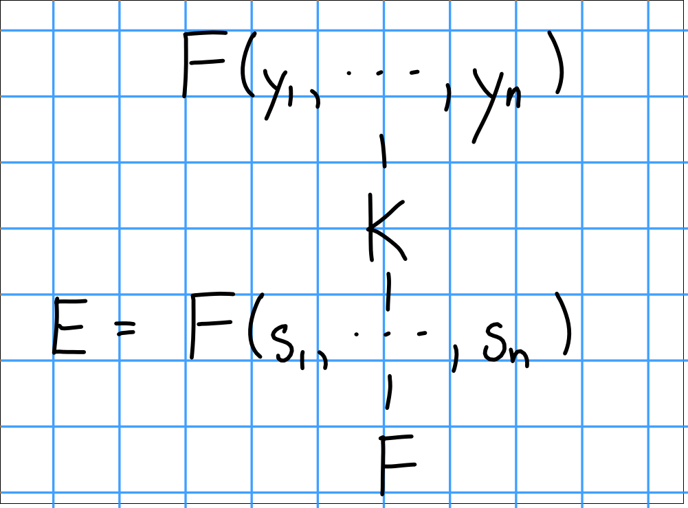

Let $K$ denote the base field with *all* symmetric functions adjoined; then $K$ is an intermediate extension, and we have the following results:

**Theorem**:

1. $E \leq K$ is a field extension.
2. $E \leq F(y_1, \cdots, y_n)$ is a finite, normal extension since it is the splitting field of $f(x) = \prod (x-y_i)$, which is separable.

We thus have
$$\begin{align*} [F(y_1, \cdots, y_n): E] \leq n! < \infty .\end{align*}$$

*Proof:*

We’ll show that in fact $E = K$, so all symmetric functions are generated by the elementary symmetric functions.

By definition of symmetric functions, $K$ is exactly the fixed field $F(y_1, \cdots, y_n)_{S_n}$, and ${\left\lvert {S} \right\rvert}_n = n!$.

So we have

$$\begin{align*} n! &= {\left\lvert { \operatorname{Gal}(F(y_1, \cdots, y_n / K))} \right\rvert} \\ & \leq \{F(y_1, \cdots, y_n) : K\} \\ & \leq [F(y_1, \cdots, y_n): K] .\end{align*}$$

But now we have
$$\begin{align*} n! \leq [F(y_1, \cdots, y_n):K] \leq [F(y_1, \cdots, y_n) : E] \leq n! \end{align*}$$
which forces $K=E$.

$\hfill\blacksquare$

**Theorem**:

1. Every symmetric function can be written as a combination of sums, products, and possibly quotients of elementary symmetric functions.
2. $F(y_1, \cdots, y_n)$ is a finite normal extension of $F(s_1, \cdots, s_n)$ of degree $n!$.
3. $\operatorname{Gal}(F(y_1, \cdots, y_n) / F(s_1, \cdots, s_n)) \cong S_n$.

We know that every group $G \hookrightarrow S_n$ by Cayley’s theorem. So there exists an intermediate extension
$$\begin{align*} F(s_1, \cdots, s_n) \leq L \leq F(y_1, \cdots, y_n) \end{align*}$$
such that $G = \operatorname{Gal}(F(y_1, \cdots, y_n) / L)$.

> Open question: which groups can be realized as Galois groups over ${\mathbb{Q}}$? Old/classic question, possibly some results in the other direction (i.e. characterizations of which groups *can’t* be realized as such Galois groups).

### Extensions by Radicals

Let $p(x) = \sum a_i x^i \in {\mathbb{Q}}[x]$ be a polynomial of degree $n$. Can we find a formula for the roots as a function of the coefficients, possibly involving radicals?

- For $n = 1$ this is clear
- For $n=2$ we have the quadratic formula.
- For $n = 3$, there is a formula by work of Cardano.
- For $n = 4$, this is true by work of Ferrari.
- For $n \geq 5$, there can **not** be a general equation.

**Definition:** Let $K \geq F$ be a field extension. Then $K$ is an **extension of $F$ by radicals** (or a **radical extension**) $\iff$ $K = \alpha_1, \cdots, \alpha_n$ for some $\alpha_i$ such that

1. Each $\alpha_i^{m_i} \in F$ for some $m_i > 0$.
2. For each $i$, $\alpha_i^{\ell_i} \in F(\alpha_1, \cdots, \alpha_{i-1})$ for some $\ell_i < m_i$ (?).

**Definition:** A polynomial $f(x) \in F[x]$ is **solvable by radicals** over $F$ $\iff$ the splitting field of $f$ is contained in some radical extension.

*Example:* Over ${\mathbb{Q}}$, the polynomials $x^5-1$ and $x^3-2$ are solvable by radicals.

Recall that $G$ is *solvable* if there exists a normal series
$$\begin{align*} 1 {~\trianglelefteq~}H_1 {~\trianglelefteq~}H_2 \cdots {~\trianglelefteq~}H_n {~\trianglelefteq~}G \text{ such that } H_n/H_{n-1} \text{ is abelian } \forall n .\end{align*}$$

### The Splitting Field of $x^n-a$ is Solvable

**Lemma**: Let $\operatorname{char}~F = 0$ and $a\in F$. If $K$ is the splitting field of $p(x) = x^n-a$, then $\operatorname{Gal}(K/F)$ is a solvable group.

*Example:* Let $p(x) = x^4-2 / {\mathbb{Q}}$, which had Galois group $D_4$.

*Proof:* Suppose that $F$ contains all $n$th roots of unity, $\left\{{1, \zeta, \zeta^2, \cdots, \zeta^[n-1]}\right\}$ where $\zeta$ is a primitive $n$th root of unity. If $\beta$ is any root of $p(x)$, then $\zeta^i\beta$ is also a root for any $1\leq i \leq n-1$. This in fact yields $n$ distinct roots, and is thus all of the them. Since the splitting field $K$ is of the form $F(\beta)$, then if $\sigma \in \operatorname{Gal}(K/F)$, then $\sigma(\beta) = \zeta^i \beta$ for some $i$. Then if $\tau \in \operatorname{Gal}(K/F)$ is any other automorphism, then $\tau(\beta) = \zeta^k \beta$ and thus (exercise) the Galois group is abelian and thus solvable.

Suppose instead that $F$ does not contain all $n$th roots of unity. So let $F' = F(\zeta)$, so $F \leq F(\zeta) = F' \leq K$. Then $F \leq F(\zeta)$ is a splitting field (of $x^n-1$) and separable since we are in characteristic zero and this is a finite extension. Thus this is a normal extension.

We thus have $\operatorname{Gal}(K/F) / \operatorname{Gal}(K/F(\zeta)) \cong \operatorname{Gal}(F(\zeta)/ F)$. We know that $\operatorname{Gal}(F(\zeta)/ F)$ is abelian since this is a cyclotomic extension, and so is $\operatorname{Gal}(K/F(\zeta))$. We thus obtain a normal series
$$\begin{align*} 1 {~\trianglelefteq~}\operatorname{Gal}(K/F(\zeta)) {~\trianglelefteq~}\operatorname{Gal}(K/F) \end{align*}$$
Thus we have a solvable group.

$\hfill\blacksquare$

# Tuesday October 22nd

## Certain Radical Extensions are Solvable

Recall the definition of an extension being *radical* (see above).

We say that a polynomial $f(x) \in K[x]$ is *solvable by radicals* iff its splitting field $L$ is a radical extension of $K$.

**Lemma:** Let $F$ be a field of characteristic zero.

If $K$ is a splitting field of $f(x) = x^n - a \in F[x]$, then $\operatorname{Gal}(K/F)$ is a solvable group.

**Theorem:** Let $F$ be characteristic zero, and suppose $F \leq E \leq K \leq \overline F$ be algebraic extension where $E/F$ is normal and $K$ a radical extension of $F$. Moreover, suppose $[K:F] < \infty$.

Then $\operatorname{Gal}(E/F)$ is solvable.

*Proof:* The claim is that $K$ is contained in some $L$ where $F \subset L$, $L$ is a finite normal radical extension, and $\operatorname{Gal}{L/F}$ is solvable.

Since $K$ is a radical extension of $F$, we have $F = K(\alpha_1, \cdots, \alpha_n)$ and $\alpha_i^{n_i} \in K(\alpha_1, \cdots, \alpha_{i-1})$ for each $i$ and some $n_i \in {\mathbb{N}}$.

Let $L_1$ be the splitting field of $f_1(x) = x^{n_1} - \alpha_1^{n_1}$, then by the previous lemma, $L_1$ is a normal extension and $\operatorname{Gal}(L_1/F)$ is a solvable group.

Inductively continue this process, and letting
$$\begin{align*} f_2(x) = \prod_{\sigma \in \operatorname{Gal}(L_1/F)} x^{n_2} - \sigma(\alpha_2)^{n_2} \in F[x] .\end{align*}$$
Note that the action of the Galois group on this polynomial is stable. Let $L_2$ be the splitting field of $f_2$, then $L_2$ is a finite normal radical extension.

Then
$$\begin{align*} \frac{ \operatorname{Gal}(L_2/F) }{ \operatorname{Gal}(L_2/L_1) } \cong \operatorname{Gal}(L_1/F) ,\end{align*}$$
which is solvable, and the denominator in this quotient is solvable, so the total group must be solvable as well. $\hfill\blacksquare$

## Proof: Insolubility of the Quintic

**Theorem (Insolubility of the quintic):** Let $y_1, \cdots, y_n$ be independent transcendental elements in ${\mathbb{R}}$, then the polynomial $f(x) = \prod (x-y_i)$ is not solvable by radicals over ${\mathbb{Q}}(s_1, \cdots, s_n)$ where the $s_i$ are the elementary symmetric polynomials in $y_i$.

> So there are no polynomial relations between the transcendental elements.

*Proof:*

Let $n\geq 5$ and suppose $y_i$ are transcendental over ${\mathbb{R}}$ and linearly independent over ${\mathbb{Q}}$. Then consider

$$\begin{align*} s_1 &= \sum y_i \\ s_2 &= \sum_{i\leq j} y_i y_j \\ \cdots \\ s_n &= \prod_i y_i .\end{align*}$$

Then ${\mathbb{Q}}(y_1, \cdots, y_n)/ {\mathbb{Q}}(s_1, \cdots, s_n)$ would be a normal extension precisely if $A_n {~\trianglelefteq~}S_n$ (by previous theorem). For $n\geq 5$, $A_n$ is simple, and thus $S_n$ is not solvable in this range.

Thus the polynomial is not solvable by radicals, since the splitting field of $f(x)$ is ${\mathbb{Q}}(y_1, \cdots, y_n)$. $\hfill\blacksquare$

## Rings and Modules

Recall that a ring is given by $(R, +, \cdot)$, where

1. $(R, +)$ is an abelian group,
2. $(R, \cdot)$ is a monoid,
3. The distributive laws hold.

An *ideal* is certain type of subring that allows taking quotients, and is defined by $I {~\trianglelefteq~}R \iff I\leq R$ and $RI, IR \subseteq I$. The quotient is given by $R/I = \left\{{r + I {~\mathrel{\Big|}~}r\in R}\right\}$, and the ideal property is what makes this well-defined.

Much like groups, we have some notion of homomorphism $\phi: R\to R'$, where $\phi(ax+y) = \phi(a)\phi(x) + \phi(y)$.

### Modules

We want to combine the following two notions:

- Groups acting on sets, and
- Vector spaces

**Definition:** Let $R$ be a ring and $M$ an abelian group. Then if there is a map
$$\begin{align*} R\times M &\to M \\ (r,m) &\mapsto rm .\end{align*}$$

such that $\forall s,r_1,r_2 \in R$ and $m_1,m_2 \in M$ we have

- $(sr_1 + r_2)(m_1 + m_2) = sr_1m_1 + sr_1m_2 + r_2m_1 + r_2 m_2$
- $1\in R \implies 1m = m$.

then $M$ is said to be an **$R{\hbox{-}}$module.**

> Think of $R$ like the group acting by scalar multiplication, and $M$ the set of vectors with vector addition.

*Examples:*

1. $R = k$ a field, then a $k{\hbox{-}}$module is a vector space.
2. $R = G$ an abelian group, then $R$ is a ${\mathbb{Z}}{\hbox{-}}$module where
   $$\begin{align*} n\curvearrowright a \mathrel{\vcenter{:}}=\sum_{i=1}^n a .\end{align*}$$

> (In fact, these two notions are equivalent.)
3. $I {~\trianglelefteq~}R$, then $M \mathrel{\vcenter{:}}= R/I$ is an ring, which has an underlying abelian group, so $M$ is an $R{\hbox{-}}$module where
   $$\begin{align*} M\curvearrowright R = r\curvearrowright(s+I) \mathrel{\vcenter{:}}=(rs) + I .\end{align*}$$
4. For $M$ an abelian group, $R \mathrel{\vcenter{:}}=\mathrm{End}(M) = \hom_{\text{AbGrp}}(M, M)$ is a ring, and $M$ is a left $R{\hbox{-}}$module given by
   $$\begin{align*} f\curvearrowright m \mathrel{\vcenter{:}}= f(m) .\end{align*}$$

**Definition:** Let $M, N$ be left $R{\hbox{-}}$modules. Then $f: M \to N$ is an $R{\hbox{-}}$module homomorphism $\iff$
$$\begin{align*} f(rm_1 + m_2) = rf(m_1) + f(m_2) .\end{align*}$$

**Definition:** *Monomorphisms* are injective maps, *epimorphisms* are surjections, and *isomorphisms* are both.

**Definition**: A *submodule* $N\leq M$ is a subset that is closed under all module operations.

We can consider images, kernels, and inverse images, so we can formulate homomorphism theorems analogous to what we saw with groups/rings:

**Theorem:**

1. If $M \xrightarrow{f} N$ in $R{\hbox{-}}$mod, then
   $$\begin{align*} M / \ker(f) \cong \operatorname{im}({(})f) .\end{align*}$$
2. Let $M, N \leq L$, then $M+N \leq L$ as well, and
   $$\begin{align*} \frac{M}{M\cap N} \cong \frac{M+N}{N} .\end{align*}$$
3. If $M\leq M\leq L$, then
   $$\begin{align*} \frac{M}{N} \cong \frac{L/M}{L/N} \end{align*}$$

> Note that we can always quotient, since there’s an underlying abelian group, and thus the “normality”/ideal condition is always satisfied for submodules. Just consider
> $$\begin{align*} M/N \mathrel{\vcenter{:}}=\left\{{m + N {~\mathrel{\Big|}~}m\in M}\right\} ,\end{align*}$$
> then $R\curvearrowright(M/N)$ in a well-defined way that gives $M/N$ the structure of an $R{\hbox{-}}$module as well.

# Thursday October 24

## Conjugates

Let $E\geq F$. Then $\alpha, \beta \in E$ are **conjugate** iff $\min(\alpha, F) = \min(\beta, F)$.

*Example:* $\alpha \pm bi \in {\mathbb{C}}$.

**Theorem:** Let $F$ be a field and $\alpha, \beta \in F$ with $\deg \min (\alpha, F) = \deg \min (\beta, F)$, so
$$\begin{align*} [F(\alpha): F] = [F(\beta): F] .\end{align*}$$

Then $\alpha, \beta$ are conjugates $\iff$ $F(\alpha) \cong F(\beta)$ under the *conjugation map*,
$$\begin{align*} \psi: F(\alpha) &\to F(\beta) \\ \sum_{i=1}^{n-1} a_i \alpha^i &\mapsto \sum_{i=1}^{n-1} a_i \beta^i .\end{align*}$$

*Proof:*

$\impliedby$:

Suppose that $\psi$ is an isomorphism. Let $\min(\alpha, F) = p(x) = \sum c_i x^i$ where each $c_i \in F$. Then
$$\begin{align*} 0 = \psi(0) = \psi(p(\alpha)) = p(\beta) \implies \min(\beta, F) {~\Bigm|~}\min(\alpha, F) .\end{align*}$$

Applying the same argument to $q(x) = \min(\beta, F)$ yields $\min(\beta, F) = \min(\alpha, F)$.

$\implies$:

Suppose $\alpha, \beta$ are conjugates.

*Exercise:* Check that $\psi$ is surjective and
$$\begin{align*} \psi(x+y) = \psi(x) + \psi(y) \\ \psi(xy) = \psi(x) \psi(y) .\end{align*}$$

Let $z = \sum a_i \alpha^i$. Supposing that $\psi(z) = 0$, we have $\sum a_i \beta^i = 0$. By linear independence, this forces $a_i = 0$ for all $i$, and thus $z=0$. So $\psi$ is injective.

$\hfill\blacksquare$

**Corollary:** Let $\alpha \in \overline F$ be algebraic. Then

1. Any $\phi: F(\alpha) \hookrightarrow\overline F$ such that $\phi(f) = f$ for all $f\in F$ must map $\alpha$ to a conjugate.
2. If $\beta \in \overline F$ is a conjugate of $\alpha$, then there exists an isomorphism $\phi: F(\alpha) \to F(\beta) \subseteq \overline F$ such that $\phi(f) = f$ for all $f\in F$.

*Proof of 1:*

Let $\min(\alpha, F) = p(x) = \sum a_i x^i$. Note that $0 = \psi(p(\alpha)) = p(\psi(\alpha))$, and since $p$ was irreducible, $p$ must also be the minimal polynomial of $\psi(\alpha)$. Thus $\psi(\alpha)$ is a conjugate of $\alpha$.

$\hfill\blacksquare$

*Proof of 2:*

$F(\alpha)$ is generated by $F$ and $\alpha$, and $\psi$ is completely determined by where it sends $F$ and $\alpha$. This shows uniquness.

$\hfill\blacksquare$

**Corollary:** Let $f(x) \in {\mathbb{R}}[x]$ and suppose $f(a+bi)= 0$. Then $f(a-bi) = 0$.

*Proof:* Both $i, -i$ are conjugates and $\min(i, {\mathbb{R}}) = \min(-i, {\mathbb{R}}) = x^2 + 1 \in {\mathbb{R}}[x]$. We then have a map
$$\begin{align*} \psi: {\mathbb{R}}[i] &\to {\mathbb{R}}[-i] \\ \psi(a+bi) = a + b(-i) .\end{align*}$$

So if $f(a+bi) = 0$, then $0 = \psi(f(a+bi)) = f(\psi(a+bi)) = f(a-bi)$.

$\hfill\blacksquare$

# October 27th

## Modules

Let $R$ be a ring and $M$ be an $R{\hbox{-}}$module.

**Definition:** For a subset $X\subseteq M$, we can define the *submodule generated by $X$* as
$$\begin{align*} \left\langle{X}\right\rangle \mathrel{\vcenter{:}}=\cap_{X \subseteq N \leq M} N \subseteq M .\end{align*}$$

Then $M$ is generated by $X$ iff $M = \left\langle{X}\right\rangle$.

As a special case, when $X = \left\{{m}\right\}$ consists of a single element, we write
$$\begin{align*} \left\langle{m}\right\rangle = Rm \mathrel{\vcenter{:}}=\left\{{rm {~\mathrel{\Big|}~}r\in R}\right\} .\end{align*}$$

In general, we have
$$\begin{align*} \left\langle{X}\right\rangle = \left\{{\sum r_i x_i \mathrel{\Big|}r_i \in R, x_i \in X}\right\} .\end{align*}$$

## Direct Products and Direct Sums

**Definition:** Let $\left\{{M_i}\right\}$ be a finite collection of $R{\hbox{-}}$modules, and let
$$\begin{align*} N = \bigoplus M_i = \left\{{\sum m_i \mathrel{\Big|}m_i \in M_i}\right\} \end{align*}$$

with multiplication given by $\gamma \sum m_i = \sum \gamma m_i$ denote the **direct sum**.

For an infinite collection, we require that all but finitely many terms are zero.

**Definition:** Define $N = \prod M_i$ denote the **direct product**, where we now drop the condition that finitely many terms are zero.

When the indexing set is finite, $\bigoplus M_i \cong \prod M_i$. In general, $\bigoplus M_i \hookrightarrow\prod M_i$.

Note that the natural inclusions
$$\begin{align*} \iota_j: M_j \hookrightarrow\prod M_i \end{align*}$$

and projections
$$\begin{align*} \pi_j: \prod M_i \twoheadrightarrow M_j \end{align*}$$

are both $R{\hbox{-}}$module homomorphisms.

Theorem: $M \cong \bigoplus M_i$ iff there exist maps $\pi_j: M \to M_j$ and $\iota_j: M_j \to M$ such that

1. $$\begin{align*} \pi_j \circ \iota_k = \begin{cases} 1m & j=k \\ 0 & \text{else}\end{cases} \end{align*}$$
2. $\sum_j \iota_j \circ \pi_j = \text{id}_M$

**Remark:** Let $M, N$ be $R{\hbox{-}}$modules. Then $\hom_{R-\text{mod}}(M, N)$ is an abelian group.

## Internal Direct Sums

For a collection of submodules of $M$ given by $\left\{{M_i}\right\}$, denote the *internal direct sum*
$$\begin{align*} \sum M_i \coloneqq\left\{{m_1 + m_2 + \cdots \mathrel{\Big|}m_i \in M_i}\right\} \end{align*}$$

iff it satisfies the following conditions:

1. $M = \sum_i M_i$
2. $M_i \cap M_j = \left\{{0}\right\}$ for $i\neq j$.

## Exact Sequences

**Definition:** A sequence of the form
$$\begin{align*} 0 \to M_1 \xrightarrow{i} M_2 \xrightarrow{p} M_3 \to 0 \end{align*}$$

where

- $i$ is a monomorphism
- $p$ is an empimorphism
- $\operatorname{im}({i}) = \ker p$

is said to be **short exact**.

*Examples*:

- $$\begin{align*} 0 \to 2{\mathbb{Z}}\hookrightarrow{\mathbb{Z}}\twoheadrightarrow{\mathbb{Z}}/2{\mathbb{Z}}\to 0 \end{align*}$$
- For any epimorphism $\pi: M\to N$,
  $$\begin{align*} 0 \to \ker \pi \to M \to N \to 0 \end{align*}$$
- $$\begin{align*} 0 \to M_1 \to M_1 \oplus M_2 \to M_2 \to 0 \end{align*}$$

In general, any sequence
$$\begin{align*} \cdots \to M_i \xrightarrow{f_i} M_{i+1} \xrightarrow{f_{i+1}} \cdots \end{align*}$$

is **exact** iff $\operatorname{im}({f})_i = \ker f_{i+1}$.

# Tuesday October 29th

## Exact Sequences

**Lemma (Short Five):**

Consider a diagram of the following form:

[figure not shown]

1. $\alpha, \gamma$ monomorphisms implies $\beta$ is a monomorphism.
2. $\alpha, \gamma$ epimorphisms implies $\beta$ is an epimorphism.
3. $\alpha, \gamma$ isomorphisms implies $\beta$ is an isomorphism.

Moreover, (1) and (2) together imply (3).

*Proof:* Exercise.

- Let $n\in N$ with $\beta(n) = 0$, then $g' \circ \beta(n) = 0$.
- $\implies \gamma \circ g (n) = 0$.
- $\implies g(n) = 0$
- $\implies \exists m\in M$ such that $f(m) = n$
- $\implies \beta \circ f (m) = \beta(n)$
- $\implies f' \alpha(m) = \beta (n) = 0$
- $\implies \alpha(m) = 0$
- $\implies f'$ is injective, so $m=0$ and $n=f(m) = 0$.

$\hfill\blacksquare$

**Theorem:** Let $0 \to M_1 \xrightarrow{f} M_2 \xrightarrow{g} M_3 \to 0$ be a SES. Then TFAE:

- There exists an $R{\hbox{-}}$module homomorphisms $h: M_3 \to M_2$ such that $g\circ h = \text{id}_{M_3}$.
- There exists an $R{\hbox{-}}$module homomorphisms $k: M_2 \to M_1$ such that $k\circ f = \text{id}_{M_1}$.
- The sequence is isomorphic to $0 \to M_1 \to M_1 \oplus M_3 \to M_3 \to 0$.

We can check that
$$\begin{align*} (g\circ \phi)(m_1 + m_2) = g( f(m_1)) + g(h(m_2)) = m_2 = \pi(m_1 + m_2).\end{align*}$$

This yields $1 \implies 3$, and $2 \implies 3$ is similar.

So define $k = \pi_1 \circ \phi^{-1}$ and $h = \phi \circ \iota_2$. It can then be checked that
$$\begin{align*} g \circ h = g \circ \phi \circ \iota_2 = \pi_2 \circ \iota_2 = \text{id}_{M_3} .\end{align*}$$

$\hfill\blacksquare$

## Free Modules

> Moral: A *free module* is a module with a basis.

**Definition:** A subset $X = \left\{{x_i}\right\}$ is *linearly independent* iff
$$\begin{align*} \sum r_i x_i = 0 \implies r_i = 0 ~\forall i .\end{align*}$$

**Definition:** A subset $X$ *spans* $M$ iff
$$\begin{align*} m\in M \implies m = \sum_{i=1}^n r_i x_i \quad \text{ for some }r_i \in R,~x_i \in X .\end{align*}$$

**Definition:** A subset $X$ is a basis $\iff$ it is a linearly independent spanning set.

*Example:* ${\mathbb{Z}}_6$ is an abelian group and thus a ${\mathbb{Z}}{\hbox{-}}$module, but not free because $3 \curvearrowright[2] = [6] = 0$, so there are torsion elements. This contradicts linear independence for any subset.

**Theorem (Characterization of Free Modules):** Let $R$ be a unital ring and $M$ a unital $R{\hbox{-}}$module (so $1\curvearrowright m = m$).

**Definition:** An $R{\hbox{-}}$module is *free* iff any of 1,2, or 3 hold.

*Proof of $1 \implies 2$:*

Let $X$ be a basis for $M$, then define $M \to \oplus_{x\in X} Rx$ by $\phi(m) = \sum r_i x_i$.

It can be checked that

- This is an $R{\hbox{-}}$module homomorphism,
- $\phi(m) = 0 \implies r_j = 0 ~\forall j \implies m = 0$, so $\phi$ is injective,
- $\phi$ is surjective, since $X$ is a spanning set.

So $M \cong \bigoplus_{x\in X} Rx$, so it only remains to show that $Rx \cong R$. We can define the map
$$\begin{align*} \pi_x: R &\to Rx \\ r &\mapsto rx .\end{align*}$$

Then $\pi_x$ is onto, and is injective exactly because $X$ is a linearly independent set. Thus $M \cong \oplus R$.

$\hfill\blacksquare$

*Proof of $1 \implies 3$:*

Let $X$ be a basis, and suppose there are two maps $X \xrightarrow{\iota} M$ and $X \xrightarrow{f} M$. Then define

$$\begin{align*} \tilde f: M &\to N \\ \sum_i r_i x_i &\mapsto \sum_i r_i f(x_i) .\end{align*}$$

This is clearly an $R{\hbox{-}}$module homomorphism, and the diagram commutes because $(\tilde f \circ \iota)(x) = f(x)$.

This is unique because $\tilde f$ is determined precisely by $f(X)$.

$\hfill\blacksquare$

*Proof of $3 \implies 2$:*

We use the usual “2 diagram” trick to produce maps
$$\begin{align*} \tilde f: M \to \bigoplus_{x\in X} R \\ \tilde g: \bigoplus_{x\in X}R \to M .\end{align*}$$

Then commutativity forces
$$\begin{align*} \tilde f \circ \tilde g = \tilde g \circ \tilde f = \text{id} .\end{align*}$$

$\hfill\blacksquare$

*Proof of $2 \implies 1$:*

We have $M = \oplus_{i\in I} R$ by (2). So there exists a map
$$\begin{align*} \psi: \oplus_{i\in I} R \to M ,\end{align*}$$

so let $X \mathrel{\vcenter{:}}=\left\{{\psi(1_i) \mathrel{\Big|}i\in I}\right\}$, which we claim is a basis.

To see that $X$ is a basis, suppose $\sum r_i \psi(1_i) = 0$. Then $\psi(\sum r_i 1_i) = 0$ and thus $\sum r_i 1_i = 0$ and $r_i = 0$ for all $i$.

Checking that it’s a spanning set: Exercise.

$\hfill\blacksquare$

**Corollary:** Every $R{\hbox{-}}$module is the homomorphic image of a free module.

*Proof:* Let $M$ be an $R{\hbox{-}}$module, and let $X$ be any set of generators of $R$. Then we can make a map
$$\begin{align*} M \to \bigoplus_{x\in X} R \end{align*}$$
and there is a map $X \hookrightarrow M$, so the universal property provides a map
$$\begin{align*} \tilde f: \bigoplus_{x\in X} R \to M .\end{align*}$$

Moreover, $\bigoplus_{x\in X} R$ is free.

$\hfill\blacksquare$

*Examples:*

- ${\mathbb{Z}}_n$ is **not** a free ${\mathbb{Z}}{\hbox{-}}$module for any $n$.
- If $V$ is a vector space over a field $k$, then $V$ is a free $k{\hbox{-}}$module (even if $V$ is infinite dimensional).
- Every nonzero submodule of a free module over a PID is free.

**Some facts:**

Let $R = k$ be a field (or potentially a division ring).

1. Every maximal linearly independent subset is a basis for $V$.
2. Every vector space has a basis.
3. Every linearly independent set is contained in a basis
4. Every spanning set contains a basis.
5. Any two bases of a vector space have the same cardinality.

**Theorem (Invariant Dimension):** Let $R$ be a commutative ring and $M$ a free $R{\hbox{-}}$module.

If $X_1, X_2$ are bases for $R$, then ${\left\lvert {X_1} \right\rvert} = {\left\lvert {X_2} \right\rvert}$.

Any ring satisfying this condition is said to have the **invariant dimension property**.

> Note that it’s difficult to say much more about generic modules. For example, even a finitely generated module may *not* have an invariant number of generators.

# Tuesday November 5th

## Free vs Projective Modules

Let $R$ be a PID. Then any nonzero submodule of a free module over a PID is free, and any projective module over $R$ is free.

Recall that a module $M$ is **projective** $\iff M$ is a direct summand of a free module.

In general,

- Free $\implies$ projective, but
- Projective $\centernot\implies$ free.

*Example:*

Consider ${\mathbb{Z}}_6 = {\mathbb{Z}}_2 \oplus {\mathbb{Z}}_3$ as a ${\mathbb{Z}}{\hbox{-}}$module. Is this free as a ${\mathbb{Z}}{\hbox{-}}$module?

Note that ${\mathbb{Z}}_2$ is a submodule and thus projective, but ${\mathbb{Z}}_2$ is not free since it is not a free module over ${\mathbb{Z}}$. What fails here is that ${\mathbb{Z}}_6$ is not a PID, since it is not a domain.

## Annihilators

**Definition:** Let $m\in M$ a module, then define
$$\begin{align*} \mathrm{Ann}_m \mathrel{\vcenter{:}}=\left\{{r\in R {~\mathrel{\Big|}~}r.m = 0 }\right\} {~\trianglelefteq~}R. \end{align*}$$
We can then define a map

$$\begin{align*} \phi: R \to R.m \\ r \mapsto r.m .\end{align*}$$

Then $\ker \phi = \mathrm{Ann}_m$, and $R/\mathrm{Ann} \cong R.m$.

We can also define
$$\begin{align*} M_t \mathrel{\vcenter{:}}=\left\{{m\in M {~\mathrel{\Big|}~}\mathrm{Ann}_m \neq 0}\right\} \leq M. \end{align*}$$

**Lemma:** Let $R$ be a PID and $p$ a prime element. Then

- If $p^i m = 0$ then $\mathrm{Ann}_m = (p^j)$ where $0\leq j\leq i$.
- If $\mathrm{Ann}_m = (p^i)$, then $p^jm \neq 0$ for any $j < m$.

*Proof of (1):* Since we are in a PID and the annihilator is an ideal, we have $\mathrm{Ann}_m \mathrel{\vcenter{:}}=(r)$ for some $r\in M$. Then $p^i \in (r)$, so $r {~\Bigm|~}p^i$. But $p$ was prime, to up to scaling by units, we have $r = p^j$ for some $j \leq i$.

$\hfill\blacksquare$

*Proof of (2):* Towards a contradiction, suppose that $\mathrm{Ann}_m = (p^i)$ and $p^jm = 0$ for some $j < i$. Then $p^j \in \mathrm{Ann}_m$, so $p^j {~\Bigm|~}p^i$. But this forces $j \leq i$, a contradiction.

$\hfill\blacksquare$

*Some terminology:*

- $\mathrm{Ann}_m$ is the **order ideal** of $m$.
- $M_t$ is the **torsion submodule** of $M$.
- $M$ is **torsion** iff $M = M_t$.
- $M$ is **torsion free** iff $M_t = 0$.
- $\mathrm{Ann}_m = (r)$ is said to have **order $r$**.
- $Rm$ is the **cyclic module** generated by $m$.

**Theorem:** A finitely generated *torsion-free* module over a PID is free.

*Proof:* Let $M = \left\langle{X}\right\rangle$ for some finite generating set.

We can assume $M \neq (0)$. If $m\neq 0 \in M$, with $rm = 0$ iff $r=0$.

So choose $S = \left\{{x_1, \cdots , x_n}\right\} \subseteq X$ to be a maximal linearly independent subset of generators, so
$$\begin{align*} \sum r_i x_i = 0 \implies r_i = 0 ~\forall i .\end{align*}$$

Consider the submodule $F \mathrel{\vcenter{:}}=\left\langle{x_1, \cdots, x_n}\right\rangle \leq M$; then $S$ is a basis for $F$ and thus $F$ is free.

The claim is that $M \cong F$. Supposing otherwise, let $y\in X\setminus S$. Then $S \cup\left\{{y}\right\}$ can not be linearly independent, so there exists $r_y, r_i \in R$ such that
$$\begin{align*} r_y y + \sum r_i x^i = 0 .\end{align*}$$
Thus $r_y y = - \sum r_i x^i$, where $r_y \neq 0$.

Since ${\left\lvert {X} \right\rvert} < \infty$, let
$$\begin{align*} r = \prod_{y \in X\setminus S} r_y .\end{align*}$$

Then $rX = \left\{{rx {~\mathrel{\Big|}~}x\in X}\right\} \subseteq F$, and $rM \leq F$.

Now using the particular $r$ we’ve just defined, define a map
$$\begin{align*} f: M &\to M \\ m &\mapsto rm .\end{align*}$$

Then $\operatorname{im}({f}) = r.M$, and since $M$ is torsion-free, $\ker f = (0)$. So $M \cong rM \subseteq F$ and $M$ is free.

$\hfill\blacksquare$

**Theorem:** Let $M$ be a finitely generated module over a PID $R$. Then $M$ can be decomposed as
$$\begin{align*} M \cong M_t \oplus F \end{align*}$$
where $M_t$ is torsion and $F$ is free of finite rank, and $F \cong M/M_t$.

> Note: we also have $M/F \cong F_t$ since this is a direct sum.

*Proof:*

*Part 1: $M/M_t$ is torsion free.*

Suppose that $r(m + M_t) = M_t$, so that $r$ acting on a coset is the zero coset. Then $rm + M_t = M_t$, so $rm \in M_t$, so there exists some $r'$ such that $r'(rm) = 0$ by definition of $M_t$. But then $(r'r)m = 0$, so in fact $m\in M_t$ and thus $m + M_t = M_t$, making $M/M_t$ torsion free.

*Part 2: $F \cong M/M_t$.*

We thus have a SES

$$\begin{align*} 0 \to M_t \to M \to M/M_t \coloneqq F \to 0 ,\end{align*}$$

and since we’ve shown that $F$ is torsion-free, by the previous theorem $F$ is free. Moreover, every SES with a free module in the right-hand slot splits:

For $X = \left\{{x_j}\right\}$ a generating set of $F$, we can choose elements $\left\{{y_i}\right\} \in \pi^{-1}(\iota(X))$ to construct a set map $f: X \to M$. By the universal property of free modules, we get a map $h: F \to M$.

It remains to check that this is actually a splitting, but we have

$$\begin{align*} \pi \circ h (x_j) = \pi(h(\iota(x_j))) = \pi(f(x_j)) = \pi(y_j) = x_j. \end{align*}$$
**Lemma:** Let $R$ be a PID, and $r\in R$ factor as $r = \prod p_i^{k_i}$ as a prime factorization. Then
$$\begin{align*} R/(r) \cong \bigoplus R/(p_i^{k_i}). \end{align*}$$

Since $R$ is a UFD, suppose that $\gcd(s ,t) = 1$. Then the claim is that
$$\begin{align*} R/(st) = R/(s) \oplus R/(t) ,\end{align*}$$
which will prove the lemma by induction.

Define a map
$$\begin{align*} \alpha: R/(s) \oplus R/(t) &\to R/(st) \\ (x + (s), y+(t)) &\mapsto tx + sy + (st) .\end{align*}$$

*Exercise*: Show that this map is well-defined.

Since $\gcd(s, t) = 1$, there exist $u, v$ such that $su + vt = 1$. Then for any $r\in R$, we have
$$\begin{align*} rsu + rvt = r ,\end{align*}$$
so for any given $r\in R$ we can pick $x =tv$ and $y=su$ so that this holds. As a result, the map $\alpha$ is onto.

Now suppose $tx + sy \in (st)$; then $tx + sy = stz$. We have $su + vt = 1$, and thus
$$\begin{align*} utx + usy = ustz \implies utx + (y-tvy) = ustz .\end{align*}$$

We can thus write
$$\begin{align*} y = ustv - utx + tvy \in (t) .\end{align*}$$

Similarly, $x\in (t)$, so $\ker \alpha = 0$.

$\hfill\blacksquare$

## Classification of Finitely Generated Modules Over a PID

**Theorem (Classification of Finitely Generated Modules over a PID):**

Let $M$ be a finitely generated $R{\hbox{-}}$module where $R$ is a PID. Then

1. $$\begin{align*} M \cong F \bigoplus_{i=1}^t R/(r_i) \end{align*}$$
   where $F$ is free of finite rank and $r_1 {~\Bigm|~}r_2 {~\Bigm|~}\cdots {~\Bigm|~}r_t$. The rank and list of ideals occurring is uniquely determined by $M$. The $r_i$ are referred to as the **invariant factors**.
2. $$\begin{align*} M \cong F \bigoplus_{i=1}^k R/(p_i^{s_i}) \end{align*}$$
   where $F$ is free of finite rank and $p_i$ are primes that need not be distinct. The rank and ideals are uniquely determined by $M$. The $p_i^{s_i}$ are referred to as **elementary divisors**.

# Thursday November 7th

## Projective Modules

**Theorem**: Every free module is projective.

$\hfill\blacksquare$

**Corollary:** Every $R{\hbox{-}}$module is the homomorphic image of a projective module.

*Proof:* If $M$ is an $R{\hbox{-}}$module, then $F \twoheadrightarrow M$ where $F$ is free, but free modules are surjective.

$\hfill\blacksquare$

**Theorem:** Let $P$ be an $R{\hbox{-}}$module. Then TFAE:

1. $P$ is projective.
2. Every SES $0 \to M \to N \to P \to 0$ splits.
3. There exists a free module $F$ such that $F = P \oplus K$ for some other module $K$.

*Proof:*

$\hfill\blacksquare$

$b \implies c$:

Suppose we have $0 \to M \to N \to P \to 0$ a SES which splits, then $N \cong M \oplus P$ by a previous theorem.

$\hfill\blacksquare$

$c\implies a$:

By the previous argument, there exists an $h: F\to M$ such that $g\circ h = f \circ \pi$. Set $\phi = h\circ \iota$.

*Exercise*: Check that $g\circ \phi = f$.

$\hfill\blacksquare$

**Theorem:** $\bigoplus P_i$ is projective $\iff$ each $P_i$ is projective.

*Proof:*

$\implies$: Suppose $\oplus P_i$ is projective.

Then there exists some $F = K \oplus \bigoplus P_i$ where $F$ is free. But then $P_i$ is a direct summand of $F$, and is thus projective.

$\impliedby$: Suppose each $P_i$ is projective.

Then there exists $F_i = P_i \oplus K_i$, so $F \mathrel{\vcenter{:}}=\bigoplus F_i = \bigoplus (P_i \oplus K_i) = \bigoplus P_i \oplus \bigoplus K_i$. So $\bigoplus P_i$ is a direct summand of a free module, and thus projective.

$\hfill\blacksquare$

> Note that a direct sum has *finitely many* nonzero terms. Can use the fact that a direct sum of free modules is still free by taking a union of bases.

*Example of a projective module that is not free:*

Take $R = {\mathbb{Z}}_6$, which is not a PID and not a domain. Then ${\mathbb{Z}}_6 = {\mathbb{Z}}_2 \oplus {\mathbb{Z}}_3$, and ${\mathbb{Z}}_2, {\mathbb{Z}}_3$ are projective $R{\hbox{-}}$modules. By previous statements, we know these are torsion as ${\mathbb{Z}}{\hbox{-}}$modules, and thus not free.

## Endomorphisms as Matrices

> See section 7.1 in Hungerford

Let $M_{m, n}({\mathbb{R}})$ denote $m\times n$ matrices with coefficients in $R$. This is an $R{\hbox{-}}R$ bimodule, and since $R$ is not necessarily a commutative ring, these two module actions may not be equivalent.

If $m=n$, then $M_{n,n}(R)$ is a ring under the usual notions of matrix addition and multiplication.

**Theorem:** Let $V, W$ be vector spaces where $\dim V = m$ and $\dim W = n$. Let $\hom_k(V, W)$ be the set of linear transformations between them.

Then $\hom_k(V, W) \cong M_{m, n}(k)$ as $k{\hbox{-}}$vector spaces.

*Proof:* Choose bases of $V, W$. Then consider

$$\begin{align*} T: V \to W \\ v_1 \mapsto \sum_{i=1}^n a_{1, i} ~w_i \\ v_2 \mapsto \sum_{i=1}^n a_{2, i} ~w_i \\ \vdots \end{align*}$$

This produces a map
$$\begin{align*} f: \hom_k(V, W) &\to M_{m, n}(k) \\ T &\mapsto (a_{i, j}) ,\end{align*}$$

which is a matrix.

> *Exercise: Check that this is bijective.*

$\hfill\blacksquare$

**Theorem:** Let $M, N$ be free left $R{\hbox{-}}$modules of rank $m, n$ respectively. Then $\hom_R(M, N) \cong M_{m, n}(R)$ as $R{\hbox{-}}R$ bimodules.

*Notation:* Suppose $M, N$ are free $R{\hbox{-}}$modules, then denote $\beta_m, \beta_n$ be fixed respective bases. We then write $[T]_{\beta_m, \beta_n} \mathrel{\vcenter{:}}=(a_{i, j})$ to be its *matrix representation*.

**Theorem**: Let $R$ be a ring and let $V, W, Z$ be three free left $R{\hbox{-}}$modules with bases $\beta_v, \beta_w, \beta_z$ respectively. If $T: V \to W, S: W\to Z$ are $R{\hbox{-}}$module homomorphisms, then $S \circ T: V \to Z$ exists and
$$\begin{align*} [S \circ T]_{\beta_v, \beta_z} = [T]_{\beta_v, \beta_w} [S]_{\beta_w, \beta_z} \end{align*}$$

*Proof:* Exercise.

Show that
$$\begin{align*} (S \circ T)(v_i) = \sum_j^t \sum_k^m a_{ik} b_{kj} z_j .\end{align*}$$

$\hfill\blacksquare$

## Matrices and Opposite Rings

Suppose $\Gamma: \hom_R(V, V) \to M_n(R)$ and $V$ is a free left $R{\hbox{-}}$module. By the theorem, we have $\Gamma(T \circ S) = \Gamma(S) \Gamma(T)$. We say that $\Gamma$ is an **anti-homomorphism**.

To address this mixup, given a ring $R$ we can define $R^{op}$ which has the same underlying set of $R$ but with the modified multiplication
$$\begin{align*} x \cdot y \mathrel{\vcenter{:}}= yx \in R .\end{align*}$$

If $R$ is commutative, then $R \cong R^{op}$.

$\hfill\blacksquare$

**Theorem**: Let $R$ be a unital ring and $V$ an $R{\hbox{-}}$module.

Then $\hom_R(V, V) \cong M_n(R^{op})$ as rings.

*Proof*: Since $\Gamma(S \circ T) = \Gamma(T) \Gamma(S)$, define a map
$$\begin{align*} \Theta: M_{n, n}(R) &\to M_{n, n}(R^{op}) \\ A &\mapsto A^t .\end{align*}$$

Then
$$\begin{align*} \Theta(AB) = (AB)^t = B^t A^t = \Theta(B) \Theta(A) ,\end{align*}$$
so $\Theta$ is an anti-isomorphism.

Thus $\Theta\circ \Gamma$ is an anti-anti-homomorphism, i.e. a usual homomorphism.

$\hfill\blacksquare$

**Definition:** A matrix $A$ is **invertible** iff there exists a $B$ such that $AB = BA = \text{id}_n$.

**Proposition:** Let $R$ be a unital ring and $V, W$ free $R{\hbox{-}}$modules with $\dim V = n, \dim W = m$. Then

1. $T \in \hom_R(V, W)$ is an isomorphisms iff $[T]_{\beta_v, \beta_w}$ is invertible.
2. $[T^{-1}]_{\beta_v, \beta_w} = [T]_{\beta_v, \beta_w}^{-1}$.

**Definition:** We’ll say that two matrices $A, B$ are **equivalent** iff there exist $P, Q$ invertible such that $PAQ = B$.

# Tuesday November 12th

## Equivalence and Similarity

Recall from last time:

If $V, W$ are free left $R{\hbox{-}}$modules of ranks $m,n$ respectively with bases $\beta_v, \beta_w$ respectively, then
$$\begin{align*} \hom_R(V, W) \cong M_{m, n}(R) .\end{align*}$$

**Definition:** Two matrices $A, B \in M_{m \times n}(R)$ are **equivalent** iff
$$\begin{align*} \exists P \in \operatorname{GL}(m, R),~ \exists Q \in \operatorname{GL}(n, R) \quad \text{ such that } \quad A = PBQ .\end{align*}$$

**Definition:** Two matrices $A, B \in M_m(R)$ are **similar** iff
$$\begin{align*} \exists P \in \operatorname{GL}(m, R) \quad \text{ such that } \quad A = P^{-1}B P .\end{align*}$$

**Theorem:** Let $T: V\to W$ be an $R{\hbox{-}}$module homomorphism.

Then $T$ has an $m\times n$ matrix relative to other bases for $V, W$ $\iff$
$$\begin{align*} B = P [T]_{\beta_v, \beta_w} Q .\end{align*}$$

*Proof*: $\implies$:

Let $\beta_v', \beta_w'$ be other bases. Then we want $B = [T]_{\beta_v', \beta_w'}$, so just let

$$\begin{align*} P = [\text{id}]_{\beta_v', \beta_v} \quad Q = [\text{id}]_{\beta_w, \beta_w'} .\end{align*}$$

$\hfill\blacksquare$

$\impliedby$:

Suppose $B = P [T]_{\beta_v, \beta_w} Q$ for some $P, Q$.

Let $g: V\to V$ be the transformation associated to $P$, and $h: W \to W$ associated to $Q^{-1}$.

Then
$$\begin{align*} P &= [\text{id}]_{g(\beta_v), \beta_v} \\ \implies Q^{-1}&= [\text{id}]_{h(\beta_w), \beta_w} \\ \implies Q &= [\text{id}]_{\beta_w, h(\beta_w)} \\ \implies B &= [T]_{g(\beta_v), h(\beta_w)} .\end{align*}$$

$\hfill\blacksquare$

**Corollary:** Let $V$ be a free $R{\hbox{-}}$module and $\beta_v$ a basis of size $n$.

Then $T: V\to V$ has an $n\times n$ matrix relative to $\beta_v$ relative to another basis $\iff$
$$\begin{align*} B = P [T]_{\beta_v, \beta_v} P^{-1} .\end{align*}$$

> Note how this specializes to the case of linear transformations, particularly when $B$ is diagonalizable.

## Review of Linear Algebra:

Let $D$ be a division ring. Recall the notions of rank and nullity, and the statement of the rank-nullity theorem.

Note that we can always factor a linear transformation $\phi: E\to F$ as the following short exact sequence:

$$\begin{align*} 0 \to \ker \phi \to E \xrightarrow{\phi} \operatorname{im}({\phi })\to 0, \end{align*}$$

and since every module over a division ring is free, this sequence splits and $E \cong \ker\phi \oplus \operatorname{im}({\phi})$. Taking dimensions yields the rank-nullity theorem.

Let $A\in M_{m, n}(D)$ and define

- $R(A) \in D^n$ is the span of the rows of $A$, and
- $C(A) \in D^m$ is the span of the columns of $A$.

Recall that finding a basis of the **row space** involves doing Gaussian Elimination and taking the rows which have nonzero pivots.

For a basis of the **column space**, you take the corresponding columns in the *original* matrix.

> Note that in this case, $\dim R(A) = \dim C(A)$, and in fact these are always equal.

**Theorem (Rank and Equivalence):** Let $\phi: V\to W$ be a linear transformation and $A$ be the matrix of $\phi$ relative to $\beta_v, \beta_v'$.

Then $\dim \operatorname{im}({\pi })= \dim C(A) = \dim R(A)$.

*Proof*: Construct the matrix $A = [\phi]_{\beta_v, \beta_w}$.

Then $\phi: V \to W$ descends to a map $A: D^m \to D^n$. Writing the matrix $A$ out and letting $v\in D^m$ a row vector act on $A$ from the *left* yields a column vector $Av \in D^n$.

But then $\operatorname{im}({\phi})$ corresponds to $R(A)$, and so
$$\begin{align*} \dim \operatorname{im}({\phi })= \dim R(A) = \dim C(A) .\end{align*}$$

$\hfill\blacksquare$

## Canonical Forms

Let $1 \leq r \leq \min(m, n)$, and define $E_r$ to be the $m\times n$ matrix with the $r\times r$ identity matrix in the top-left block.

**Theorem**: Let $A, B \in M_{m,n}(D)$. Then

1. $A$ is equivalent to $E_r \iff \operatorname{rank}A = r$
   - That is, $\exists P,Q$ such that $E_r = PAQ$
2. $A$ is equivalent to $B$ iff $\operatorname{rank}A = \operatorname{rank}B$.
3. $E_r$ for $r = 0, 1, \cdots, \min(m,n)$ is a complete set of representatives for the relation of matrix equivalence on $M_{m, n}(D)$.

Let $X = M_{m, n}(D)$ and $G = \operatorname{GL}_m(D) \times\operatorname{GL}_n(D)$, then
$$\begin{align*} G \curvearrowright X \text{ by } (P, Q) \curvearrowright A \mathrel{\vcenter{:}}= PAQ^{-1} .\end{align*}$$
Then the orbits under this action are exactly $\left\{{E_r \mathrel{\Big|}0 \leq r \leq \min(m, n)}\right\}$.

*Proof*: Note that 2 and 3 follow from 1, so we’ll show 1.

$\implies$:

Let $A$ be an $m\times n$ matrix for some linear transformation $\phi: D^m \to D^n$ relative to some basis. Assume $\operatorname{rank}A = \dim \operatorname{im}({\phi })= r$. We can find a basis such that $\phi(u_i) = v_i$ for $1 \leq i \leq r$, and $\phi(u_i) = 0$ otherwise. Relative to this basis, $[\phi] = E_r$. But then $A$ is equivalent to $E_r$.

$\impliedby$:

If $A = PE_r Q$ with $P, Q$ invertible, then $\dim \operatorname{im}({A}) = \dim \operatorname{im}({E})_r$, and thus $\operatorname{rank}A = \operatorname{rank}E_r = r$.

How do we do this? Recall the row operations:

- Interchange rows
- Multiply a row by a unit
- Add one row to another

But each corresponds to left-multiplication by an elementary matrix, each of which is invertible. If you proceed this way until the matrix is in RREF, you produce $P \prod P_i A$. You can now multiply on the *right* by elementary matrices to do column operations and move all pivots to the top-left block, which yields $E_r$.

$\hfill\blacksquare$

**Theorem:** Let $A \in M_{m, n}(R)$ where $R$ is a PID.

Then $A$ is equivalent to a matrix with $L_r$ in the top-left block, where $L_r$ is a diagonal matrix with $L_{ii} = d_i$ such that $d_1 {~\Bigm|~}d_2 {~\Bigm|~}\cdots {~\Bigm|~}d_r$. Each $(d_i)$ is uniquely determined by $A$.

# Thursday November 14th

## Equivalence to Canonical Forms

Let $D$ be a division ring and $k$ a field.

Recall that a matrix $A$ is *equivalent* to $B \iff \exists P, Q$ such that $PBQ=A$. From a previous theorem, if $\operatorname{rank}(A) = r$, then $A$ is equivalent to a matrix with $I_r$ in the top-left block.

**Theorem:** Let $A$ be a matrix over a PID $R$. Then $A$ is equivalent to a matrix with $L_r$ in the top-left corner, where $L_r = \mathrm{diag}(d_1, d_2, \cdots, d_r)$ and $d_1 {~\Bigm|~}d_2 {~\Bigm|~}\cdots {~\Bigm|~}d_r$, and the $d_i$ are uniquely determined.

**Theorem:** Let $A$ be an $n\times n$ matrix over a division ring $D$. TFAE:

1. $\operatorname{rank}A = n$.
2. $A$ is equivalent to $I_n$.
3. $A$ is invertible.

$1\implies 2$: Use Gaussian elimination.

$2\implies 3$: $A = PI_n Q = PQ$ where $P, Q$ are invertible, so $PQ = A$ is invertible.

$3\implies 1$: If $A$ is invertible, then $A: D^n \to D^n$ is bijective and thus surjective, so $\dim \operatorname{im}({A}) = n$.

> Note: the image is now *row space* because we are taking *left* actions.

$\hfill\blacksquare$

## Determinants

**Definition:** Let $M_1, \cdots, M_n$ be $R{\hbox{-}}$modules, and then $f: \prod M_i \to R$ is $n{\hbox{-}}$linear iff

$$\begin{align*} f( m_1, m_2, \cdots, rm_k + sm_k', \cdots, m_n ) = \\ r f( m_1, \cdots, m_k, \cdots m_k) + sf(m_1, \cdots, m_k', \cdots, m_n ) .\end{align*}$$

*Example:* The inner product is a 2-linear form.

**Definition:** $f$ is **symmetric** iff
$$\begin{align*} f(m_1, \cdots, m_n) = f(m_{\sigma(1)}, \cdots, m_{\sigma(n)}) ~~\forall \sigma \in S_n .\end{align*}$$

**Definition:** $f$ is **skew-symmetric** iff
$$\begin{align*} f(m_1, \cdots, m_n) = \mathrm{sgn}(\sigma) f(m_{\sigma(1)}, \cdots, m_{\sigma(n)}) ~~\forall \sigma \in S_n ,\end{align*}$$

where

$$\begin{align*} \mathrm{sgn}(\sigma) = \begin{cases} 1 & \sigma \text{ is even } \\ -1 & \sigma \text{ is odd } \end{cases} .\end{align*}$$

**Definition:** $f$ is **alternating** iff

$$\begin{align*} m_i = m_j \text{ for some pair } (i, j) \implies f(m_1, \cdots, m_n) = 0 .\end{align*}$$

**Theorem:** Let $f$ be an $n{\hbox{-}}$linear form. If $f$ is alternating, then $f$ is skew-symmetric.

*Proof:* It suffices to show the $n=2$ case. We have

$$\begin{align*} 0 &= f(m+1 + m_2, m_1 + m_2) \\ &= f(m_1, m_1) + f(m_1, m_2) + f(m_2, m_1) + f(m_2, m_2) \\ &= f(m_1, m_2) + f(m_2, m_1)\\ \implies f(m_1, m_2) &= - f(m_2, m_1) .\end{align*}$$

$\hfill\blacksquare$

**Theorem:** Let $R$ be a unital commutative ring and let $r\in R$ be arbitrary.

Then
$$\begin{align*} \exists! f: \bigoplus_{i=1}^n R^n \to R ,\end{align*}$$

where $f$ is an alternating $R{\hbox{-}}$form such that $f(\mathbf{e}_i) = r$ for all $i$, where $\mathbf{e}_i = [0, 0, \cdots, 0, 1, 0, \cdots, 0, 0]$.

> $R^n$ is a free module, so $f$ can be identified with a matrix once a basis is chosen.

*Proof*:

*Existence:* Let $x_i = [a_{i1}, a_{i2}, \cdots, a_{in}]$ and define
$$\begin{align*} f(x_1, \cdots, x_n) = \sum_{\sigma \in S_n} \mathrm{sgn}(\sigma) r \prod_i a_{i \sigma(i)} .\end{align*}$$

*Exercise:* Check that $f(\mathbf{e}_1, \cdots, \mathbf{e}_n) = r$ and $f$ is $n{\hbox{-}}$linear.

Moreover, $f$ is alternating. Consider $f(x_1, \cdots, x_n)$ where $x_i = x_j$ for some $i\neq j$.

Letting $\phi = (i, j)$, we can write $S_n = A_n {\coprod}A_n \rho$.

If $\sigma$ is even, then the summand is
$$\begin{align*} (+1)r a_{1\sigma(1)} \cdots a_{n\sigma(n)} .\end{align*}$$

Since $x_i = x_j$, we’ll have $\prod_k a_{ik} = \prod a_{jk}$. Then consider applying $\sigma \rho$. We have

$$\begin{align*} -r \prod a_{i\sigma(i)} &= -r a_{1\sigma(1)} \cdots \mathbf{a}_{j \sigma(j)} \cdots \mathbf{a}_{i \sigma(i)} \cdots a_{n, \sigma(n)} \\ &= -r \prod a_{i\sigma(i)} = -r a_{1\sigma(1)} \cdots \mathbf{a}_{i \sigma(i)} \cdots \mathbf{a}_{j \sigma(j)} \cdots a_{n, \sigma(n)} ,\end{align*}$$

which permutes the $i,j$ terms. So these two terms cancel, the remaining terms are untouched.

*Uniqueness*: Let $x_i = \sum_j a_{ij} \mathbf{e}_j$. Then

$$\begin{align*} f(x_1, \cdots, x_n) &= f(\sum_{j_1} a^1_j \mathbf{e}_j, \cdots, \sum_{j_n} a^n_j \mathbf{e}_j) \\ &= \sum_{j_1} \cdots \sum_{j_n} f(\mathbf{e}_{j_1}, \cdots, \mathbf{e}_{j_n} ) a_{1, j_1} \cdots a_{n, j_n} \\ &= \sum_{\sigma \in S_n} \mathrm{sgn}(\sigma) f(\mathbf{e}_1, \cdots, \mathbf{e}_n) a_{1, \sigma(1)} \cdots a_{n, \sigma(n)} \\ &= \sum_{\sigma \in S_n} \mathrm{sgn}(\sigma) r a_{1, \sigma(1)} \cdots a_{n, \sigma(n)} .\end{align*}$$

$\hfill\blacksquare$

**Definition:** Let $R$ be a commutative unital ring and define $\mathrm{det}: M_n(R) \to R$ is the unique $n{\hbox{-}}$alternating form with $\det(I) = 1$, and is called the *determinant*.

**Theorem:** Let $A, B \in M_{n}(R)$. Then

1. ${\left\lvert {AB} \right\rvert} = {\left\lvert {A} \right\rvert} {\left\lvert {B} \right\rvert}$
2. $A$ is invertible $\iff {\left\lvert {A} \right\rvert} \in R^{\times}$
3. $A \sim B \implies {\left\lvert {A} \right\rvert} = {\left\lvert {B} \right\rvert}$.
4. ${\left\lvert {A^t} \right\rvert} = {\left\lvert {A} \right\rvert}$.
5. If $A$ is triangular, then ${\left\lvert {A} \right\rvert}$ is the product of the diagonal entries.

*Proof of a:* Let $B$ be fixed.

Let $\Delta_B: M_n(R) \to R$ be defined as $C \mapsto {\left\lvert {CB} \right\rvert}$. Then this is an alternating form, so by the theorem, $\Delta_B = r \mathrm{det}$. But then $\Delta_B(C) = r{\left\lvert {C} \right\rvert}$, so $r{\left\lvert {C} \right\rvert} = {\left\lvert {CB} \right\rvert}$. So pick $C = I$, then $r = {\left\lvert {B} \right\rvert}$.

$\hfill\blacksquare$

*Proof of b:* Suppose $A$ is invertible.

Then $AA^{-1}= I$, so ${\left\lvert {AA^{-1}} \right\rvert} = {\left\lvert {A} \right\rvert}{\left\lvert {A^{-1}} \right\rvert} = 1$, which shows that ${\left\lvert {A} \right\rvert}$ is a unit.

$\hfill\blacksquare$

*Proof of c:* Let $A = PBP^{-1}$. Then
$$\begin{align*} {\left\lvert {A} \right\rvert} = {\left\lvert {PBP^{-1}} \right\rvert} = {\left\lvert {P} \right\rvert} {\left\lvert {B} \right\rvert} {\left\lvert {P^{-1}} \right\rvert} = {\left\lvert {P} \right\rvert} {\left\lvert {P^{-1}} \right\rvert} {\left\lvert {B} \right\rvert} = {\left\lvert {B} \right\rvert} .\end{align*}$$

$\hfill\blacksquare$

*Proof of d:* Let $A = (a_{ij})$, so $B = (b_{ij}) = (a_{ji})$. Then

$$\begin{align*} {\left\lvert {A^t} \right\rvert} &= \sum_{\sigma} \mathrm{sgn}(\sigma) \prod_k b_{k \sigma(k)} \\ &= \sum_\sigma \mathrm{sgn}(\sigma) \prod_k a_{\sigma(k) k} \\ &= \sum_{\sigma^{-1}} \mathrm{sgn}(\sigma) \prod_k a_{k \sigma^{-1}(k)} \\ &= \sum_\sigma \mathrm{sgn}(\sigma) \prod_k a_{k \sigma(k)} \\ &= {\left\lvert {A} \right\rvert} .\end{align*}$$

$\hfill\blacksquare$

*Proof of e:* Let $A$ be upper-triangular. Then
$$\begin{align*} {\left\lvert {A} \right\rvert} = \sum_\sigma \mathrm{sgn}(\sigma) \prod_k a_{k \sigma(k)} = a_{11} a_{22} \cdots a_{nn} .\end{align*}$$

$\hfill\blacksquare$

Next time:

- Calculate determinants
  - Gaussian elimination
  - Cofactors
- Formulas for $A^{-1}$
- Cramer’s rule

# Tuesday November 19th

## Determinants

Let $A\in M_n(R)$, where $R$ is a commutative unital ring.

Given $A = (a_{ij})$, recall that
$$\begin{align*} \det A = \sum_{\sigma \in S_n} \mathrm{sgn}(\sigma) \prod a_{i, \sigma(i)} .\end{align*}$$

This satisfies a number of properties:

- $\det(AB) = \det A \det B$
- $A$ invertible $\implies$ $\det A$ is a unit in $R$
- $A \sim B \implies \det(A) = \det(B)$
- $\det A^t = \det A$
- $A$ is triangular $\implies \det A = \prod a_{ii}$.

### Calculating Determinants

1. **Gaussian Elimination**
   1. $B$ is obtained from $A$ by interchanging rows: $\det B = -\det A$
   2. $B$ is obtained from $A$ by multiplying $\det B = r \det A$
   3. $B$ is obtained from $A$ by adding a scalar multiple of one row to another: $\det B = \det A$.
2. **Cofactors** Let $A_{ij}$ be the $(n-1)\times (n-1)$ minor obtained by deleting row $i$ and column $j$, and $C_{ij} = (-1)^{i+j} \det A_{ij}$.

   Then **(theorem)** $\det A = \sum_{j=1}^n a_{ij} C_{ij}$ by expanding along either a row or column.

**Theorem**:
$$\begin{align*} A \mathrm{Adj}(A) = \det (A) I_n ,\end{align*}$$
where $\mathrm{Adj} = (C_{ij})^t$.

If $A^{-1}$ is a unit, then $A^{-1}= \mathrm{Adj}(A) / \det(A)$.

### Decomposition of a Linear Transformation:

Let $\phi: V \to V$ be a linear transformation of vector spaces. and $R = \hom_k(V, V)$. Then $R$ is a ring.

Let $f(x) = \sum a_j x^j \in k[x]$ be an arbitrary polynomial. Then for $\phi \in R$, it makes sense to evaluate $f(\phi)$ where $\phi^n$ denotes an $n{\hbox{-}}$fold composition, and $f(\phi): V \to V$.

**Lemma:**

- There exists a unique monic polynomial $q_\phi(x) \in k[x]$ such that $q_\phi(\phi) = 0$ and $f(\phi) = 0 \implies q_\phi {~\Bigm|~}f$. $q_\phi$ is referred to as the **minimal polynomial** of $\phi$.
- The exact same conclusion holds with $\phi$ replaced by a matrix $A$, yielding $q_A$.
- If $A$ is the matrix of $\phi$ relative to a fixed basis, then $q_\phi = q_A$.

*Proof of a and b:* Fix $\phi$, and define

$$\begin{align*} \Gamma: k[x] &\to \hom_k(V, V) \\ f &\mapsto f(\phi) .\end{align*}$$

Since $\dim_k V^\vee= \dim_k V < \infty$ and $\dim_k k[x] = \infty$, we must have $\ker \Gamma \neq 0$.

Since $k[x]$ is a PID, we have $\ker \Gamma = (q)$ for some $q\in k[x]$. Then if $f(\phi) = 0$, we have $f(x) \in \ker \Gamma \implies q {~\Bigm|~}f$. We can then rescale $q$ to be monic, which makes it unique.

> Note: for (b), just replace $\phi$ with $A$ everywhere.

$\hfill\blacksquare$

*Proof of c:* Suppose $A = [\phi]_\mathcal{B}$ for some fixed basis $\mathcal B$.

$\hfill\blacksquare$

### Finitely Generated Modules over a PID

Let $M$ be a finitely generated module over $R$ a PID. Then

$$\begin{align*} M &\cong F \oplus \bigoplus_{i=1}^n R/(r_i) \quad r_1 {~\Bigm|~}r_2 {~\Bigm|~}\cdots r_n \\ M &\cong F \oplus \bigoplus_{i=1}^n R/(p_i^{s_i}) \quad p_i \text{ not necessarily distinct primes. } .\end{align*}$$

Letting $R = k[x]$ and $\phi: V\to V$ with $\dim_k V < \infty$, $V$ becomes a $k[x]{\hbox{-}}$module by defining
$$\begin{align*} f(x) \curvearrowright\mathbf{v} \mathrel{\vcenter{:}}= f(\phi)(\mathbf{v}) \end{align*}$$

Note that $W$ is a $k[x]{\hbox{-}}$submodule iff $\phi: W \to W$.

Let $v\in V$, and $\left\langle{v}\right\rangle = \left\{{\phi^i(v) {~\mathrel{\Big|}~}i = 0,1,2,\cdots}\right\}$ is the **cyclic submodule generated by $v$**, and we write $\left\langle{v}\right\rangle = k[x].v$.

**Theorem:** Let $\phi: V\to V$ be a linear transformation. Then

1. There exist cyclic $k[x]{\hbox{-}}$submodules $V_i$ such that $V = \bigoplus_{i=1}^t V_i$, where for each $i$ there exists a $q_i: V_i \to V_i$ such that $q_1 {~\Bigm|~}q_2 {~\Bigm|~}\cdots {~\Bigm|~}q_t$.
2. There exist cyclic $k[x]{\hbox{-}}$submodules $V_j$ such that $V = \bigoplus_{j=1}^\nu$ and $p_j^{m_j}$ is the minimal polynomial of $\phi: V_j \to V_j$.

*Proof:* Apply the classification theorem to write $V = \bigoplus R/(r_i)$ as an invariant factor decomposition.

Then $R/(q_i) \cong V_i$, some vector space, and since there is a direct sum decomposition, the invariant factors are minimal polynomials for $\phi_i: V_i \to V_i$, and thus $k[x]/(q_i)$.

$\hfill\blacksquare$

### Canonical Forms for Matrices

We’ll look at

- Rational Canonical Form
- Jordan Canonical Form

**Theorem**: Let $\phi: V\to V$ be linear, then $V$ is a cyclic $k[x]{\hbox{-}}$module and $\phi: V\to V$ has minimal polynomial $q(x) = \sum_j a_j x^j$ iff $\dim V = n$ and $V$ has an ordered basis of the form

$$\begin{align*} [\phi]_{\mathcal{B}} = \left[ \begin{array}{ccccc} 0 & 1 & 0 & \cdots & 0 \\ 0 & 0 & 1 & \cdots & 0 \\ \vdots & \vdots & \vdots & \cdots & \vdots \\ -a_0 & -a_1 & -a_2 & \cdots & -a_{n-1} \end{array} \right] \end{align*}$$

with ones on the super-diagonal.

*Proof:*

$\impliedby$:

Let $V = k[x].v = \left\langle{v, \phi(v), \cdots, \phi^{n-1}(v)}\right\rangle$ where $\deg q(x) = n$. The claim is that this is a linearly independent spanning set.

Linear independence: suppose $\sum_{j=0}^{n-1} k_j \phi^j(v) = 0$ with some $k_j \neq 0$. Then $f(x) = \sum k_j x^j$ is a polynomial where $f(\phi) = 0$, but this contradicts the minimality of $q(x)$.

But then we have $n$ linearly independent vectors in $V$ which is dimension $n$, so this is a spanning set.

$\implies$:

We can just check where basis elements are sent. Set $\mathcal{B} = \left\{{v, \phi(v), \cdots, \phi^{n-1}(v)}\right\}$. Then

$$\begin{align*} v &\mapsto \phi(v) \\ \phi(v) &\mapsto \phi^2(v) \\ &\vdots \\ \phi{n-1}(v) &\mapsto \phi^n(v) = -\sum a_i \phi^i(v) \\ .\end{align*}$$

$\impliedby$ Fix a basis $B = \left\{{v_1, \cdots, v_n}\right\}$ and $A = [\phi]_B$, then

$$\begin{align*} v_1 &\mapsto v_2 = \phi(v_1) \\ v_1 &\mapsto v_3 = \phi^2(v_1) \\ v_{n-2} &\mapsto v_{n-1} = \phi^2(v_1) .\end{align*}$$

and
$$\begin{align*} \phi^n(v) = -a_k v_1 \neq -a_1 \phi(v_1), \cdots -a_{n-1} \phi^{n-1}(v_1) .\end{align*}$$

Thus $V = k[x].v_1$, since $\dim V = n$ with $\left\{{v_1, \phi(v_1), \cdots, \phi^{n-1}(v_1)}\right\}$ as a basis.

$\hfill\blacksquare$

# Thursday November 21

## Cyclic Decomposition

Let $\phi: V\to V$ be a linear transformation; then $V$ is a $k[x]$ module under $f(x) \curvearrowright v \mathrel{\vcenter{:}}= f(\phi)(v)$.

By the structure theorem, since $k[x]$ is a PID, we have an invariant factor decomposition $V = \bigoplus V_i$ where each $V_i$ is a cyclic $k[x]{\hbox{-}}$module. If $q_i$ is the minimal polynomial for $\phi_i: V_i \to V_i$, then $q_{i} {~\Bigm|~}q_{i+1}$ for all $i$.

We also have an elementary divisor decomposition where $p_i^{m_i}$ are the minimal polynomials for $\phi_i$.

> Note: one is only for the restriction to the subspaces? Check.

Recall that if $\phi$ has minimal polynomial $q(x)$. Then if $\dim V = n$, there exists a basis of $B$ if $V$ such that $[\phi]_B$ is given by the **companion matrix** of $q(x)$. This is the **rational canonical form**.

**Corollary:** Let $\phi: V\to V$ be a linear transformation. Then $V$ is a cyclic $k[x]{\hbox{-}}$module and $\phi$ has minimal polynomial $(x-b)^n \iff \dim V = n$ and there exists a basis such that

$$\begin{align*} [\phi]_B = \left[\begin{array}{ccccccc} b & 1 & 0 & \cdots & 0 & 0 & 0\\ 0 & b & 1 & \cdots & 0 & 0 & 0\\ 0 & 0 & b & 1 &\cdots & 0 & 0\\ 0 & 0 & 0 & 0 & \cdots & b & 1 \end{array}\right] .\end{align*}$$

This is the **Jordan Canonical form**.

> Note that if $k$ is not algebraically closed, we can only reduce to RCF. If $k$ *is* closed, we can reduce to JCF, which is slightly nicer.

*Proof:*

Let $\delta = \phi - b \cdot\text{id}_V$. Then

- $q(x)$ is the minimal polynomial for $\phi \iff x^n$ is the minimal polynomial for $\delta$.
- A priori, $V$ has two $k[x]$ structures – one given by $\phi$, and one by $\delta$.
- *Exercise*: $V$ is cyclic with respect to the $\phi$ structure $\iff$ $V$ is cyclic with respect to the the $\delta$ structure.

Then the matrix $[\delta]_B$ relative to an ordered basis for $\delta$ is with only zeros on the diagonal and 1s on the super-diagonal, and $[\phi]_B$ is the same but with $b$ on the diagonal.

$\hfill\blacksquare$

**Lemma:** Let $\phi: V\to V$ with $V = \bigoplus_i^t V_i$ as $k[x]{\hbox{-}}$modules. Then $M_i$ is a matrix of ${\left.{\phi}\right|_{V_i}}: V_i \to V_i$ relative to some basis for $V_i \iff$the matrix of $\phi$ wrt some ordered basis is given by

$$\begin{align*} \left[ \begin{array}{cccc} M_1 & & & \\ & M_2 & & \\ & & \ddots & \\ & & & M_t \end{array}\right] .\end{align*}$$

*Proof*:

$\implies$: Suppose $B_i$ is a basis for $V_i$ and $[\phi]_{B_i} = M_i$. Then let $B = \cup_i B_i$; then $B$ is a basis for $V$ and the matrix is of the desired form.

$\impliedby$: Suppose that we have a basis $B$ and $[\phi]_B$ is given by a block diagonal matrix filled with blocks $M_i$. Suppose $\dim M_i = n_i$. If $B = \left\{{v_1, v_2, \cdots, v_n}\right\}$, then take $B_1 = \left\{{v_1, \cdots, v_{n_1}}\right\}$ and so on. Then $[\phi_i]_{B_i} = M_i$ as desired.

$\hfill\blacksquare$

*Application:* Let $V = \bigoplus V_i$ with $q_i$ the minimal polynomials of $\phi: V_i \to V_i$ with $q_i {~\Bigm|~}q_{i+1}$.

Then there exists a basis where $[\phi]_B$ is block diagonal with blocks $M_i$, where each $M_i$ is in rational canonical form with minimal polynomial $q_i(x)$. If $k$ is algebraically closed, we can obtain elementary divisors $p_i(x) = (x - b_i)^{m_i}$. Then there exists a similar basis where now each $M_i$ is a *Jordan block* with $b_i$ on the diagonals and ones on the super-diagonal.

Moreover, in each case, there is a basis such that $A = P [M_i] P^{-1}$ (where $M_i$ are the block matrices obtained). When $A$ is diagonalizable, $P$ contains the eigenvectors of $A$.

**Corollary:** Two matrices are similar $\iff$ they have the same invariant factors and elementary divisors.

*Example:* Let $\phi: V\to V$ have invariant factors $q_1(x) = (x-1)$ and $q_2(x) = (x-1)(x-2)$.

Then $\dim V = 3$, $V = V_1 \oplus V_2$ where $\dim V_1 = 1$ and $\dim V_2 = 2$. We thus have

$$\begin{align*} [\phi]_B = \left(\begin{array}{ccc} 1 & 0 & 0 \\ 0 & 0 & 1 \\ 0 & -2 & 3 \end{array}\right) .\end{align*}$$

Moreover, we have

$$\begin{align*} V \cong \frac{k[x]}{(x-1)} \oplus \frac{k[x]}{(x-1)(x-2)} \cong \frac{k[x]}{(x-1)} \oplus \frac{k[x]}{(x-1)} \oplus \frac{k[x]}{(x-2)} ,\end{align*}$$

so the elementary divisors are $x-1, x-1, x-2$.

> Invariant factor decompositions should correspond to rational canonical form blocks, and elementary divisors should correspond to Jordan blocks.

**Theorem:** Let $A$ be an $n\times n$ matrix over $k$. Then the matrix $xI_n - A \in M_n(k[x])$ is equivalent in $k[x]$ to a diagonal matrix $D$ with non-zero entries $f_1, f_2, \cdots f_t \in k[x]$ such that the $f_i$ are monic and $f_i {~\Bigm|~}f_{i+1}$. The non-constant polynomials among the $f_i$ are the invariant factors of $A$.

*Proof (Sketch)*: Let $V = k^n$ and $\phi: k^n \to k^n$ correspond to $A$ under the fixed standard basis $\left\{{e_i}\right\}$. Then $V$ has a $k[x]{\hbox{-}}$module structure induced by $\phi$.

Let $F$ be the free $k[x]$ module with basis $\left\{{u_i}\right\}_{i=1}^n$, and define the maps

$$\begin{align*} \pi: F &\to k^n \\ u_i &\mapsto e_i \end{align*}$$

and

$$\begin{align*} \psi: F &\to F \\ u_i &\mapsto xu_i - \sum_j a_{ij} u_j .\end{align*}$$

Then $\psi$ relative to the basis $\left\{{u_i}\right\}$ is $xI_n - A$.

Then *(exercise)* the sequence
$$\begin{align*} F \xrightarrow{\psi} F \xrightarrow{\pi} k^n \to 0 \end{align*}$$
is exact, $\operatorname{im}({\pi })= k^n$, and $\operatorname{im}({\psi })= \ker \pi$.

We then have $k^n \cong F/\ker \pi = F / \operatorname{im}({\psi})$, and since $k[x]$ is a PID,

$$\begin{align*} xI_n - A \sim D \coloneqq \left[\begin{array}{cc} L_r & 0 \\ 0 & 0 \end{array}\right] .\end{align*}$$

where $L_r$ is diagonal with $f_i$s where $f_i {~\Bigm|~}f_{i+1}$.

However, $\det(xI_n - A) \neq 0$ because $x I_n - A$ is a monic polynomial of degree $n$.

But $\det{xI_n - A} = \det(D)$, so this means that $L_r$ must take up the entire matrix of $D$, so there is no zero in the bottom-right corner. So $L_r = D$, and $D$ is the matrix of $\psi$ with respect to $B_1 = \left\{{v_i}\right\}$ and $B_2 = \left\{{w_i}\right\}$ with $\psi(v_i) = f_i w_i$.

Thus
$$\begin{align*} \operatorname{im}({\psi })= \bigoplus_{i=1}^n k[x] f_i w_i. \end{align*}$$

But then
$$\begin{align*} V = k^n \cong F/ \operatorname{im}({\psi}) &\cong \frac{k[x] w_1 \oplus \cdots \oplus k[x] w_n} {k[x] f_1 w_1 \oplus \cdots \oplus k[x] f_n w_n} \\ &\cong \bigoplus_{i=1}^n k[x]/(f_i) .\end{align*}$$

$\hfill\blacksquare$

# Tuesday November 26th

## Minimal and Characteristic Polynomials

$\hfill\blacksquare$

*Proof of (b):*

If $q_\phi(x) {~\Bigm|~}p_\phi(x)$ and $q_\phi(\phi) = 0$, then $p_\phi(\phi) = 0$ as well.

$\hfill\blacksquare$

*Proof of (c):* We have $f(x) {~\Bigm|~}q_\phi(x) \implies f(x) {~\Bigm|~}p_\phi(x)$ and $f(x) {~\Bigm|~}p_\phi(x) \implies f(x) {~\Bigm|~}q_i(x)$ for some $i$, and so $f(x) {~\Bigm|~}q_\phi(x)$.

$\hfill\blacksquare$

## Eigenvalues and Eigenvectors

**Definition:** Let $\phi: V\to V$ be a linear transformation. Then

1. An **eigenvector** is a vector $\mathbf{v} = \mathbf{0}$ such that $\phi(\mathbf{v}) = \lambda \mathbf{v}$ for some $\lambda \in k$.
2. If such a $\mathbf{v}$ exists, then $\lambda$ is called an **eigenvalue** of $\phi$.

**Theorem:** The eigenvalues of $\phi$ are the roots of $p_\phi(x)$ in $k$.

*Proof:* Let $[\phi]_B = A$, then

$$\begin{align*} &p_A(\lambda) = p_\phi(\lambda) = \det(\lambda I - A) = 0 \\ &\iff \exists \mathbf{v}\neq \mathbf{0} \text{ such that } (\lambda I - A)\mathbf{v} = \mathbf{0} \\ &\iff \lambda I\mathbf{v} = A \mathbf{v} \\ &\iff A\mathbf{v} = \lambda \mathbf{v} \\ &\iff \lambda \text{ is an eigenvalue and } \mathbf{v} \text{ is an eigenvector} .\end{align*}$$

$\hfill\blacksquare$

# Tuesday December 3rd

## Similarity and Diagonalizability

Recall that $A \sim B \iff A = PBP^{-1}$.

*Fact:* If $T:V \to V$ is a linear transformation and $\mathcal{B}, \mathcal{B}'$ are bases where $[T]_{\mathcal{B}} = A$ and $[T]_{\mathcal{B}'}$, then $A \sim B$.

**Theorem:** Let $A$ be an $n\times n$ matrix. Then

1. $A$ is similar to a diagonal matrix / diagonalizable $\iff A$ has $n$ linearly independent eigenvectors.
2. $A = PDP^{-1}$ where $D$ is diagonal and $P = [\mathbf{v_1}, \mathbf{v_2}, \cdots, \mathbf{v_n}]$ with the $\mathbf{v_i}$ linearly independent.

*Proof:* Consider $AP = PD$, then $AP$ has columns $A\mathbf{v_i}$ and $PD$ has columns $\lambda_i \mathbf{v_i}$. $\hfill\blacksquare$

*Corollary:* If $A$ has distinct eigenvalues, then $A$ is diagonalizable.

*Examples:*

1. Let
   $$\begin{align*} A = \left[\begin{array}{ccc} 4 & 0 & 0 \\ -1 & 4 & 0 \\ 0 & 0 & 5 \end{array}\right] \end{align*}$$

   $A$ has eigenvalues $4,5$, and it turns out that $A$ is defective.

   Note that $\dim \Lambda_4 + \dim \Lambda_5 = 2 < 3$, so the eigenvectors can’t form a basis of ${\mathbb{R}}^3$.
2. $$\begin{align*} A = \left[\begin{array}{ccc} 4 & 2 & 2 \\ 2 & 4 & 2 \\ 2 & 2 & 4 \end{array}\right] \end{align*}$$
   $A$ has eigenvalues $2, 8$. $\Lambda_2 = {\operatorname{span}}_{\mathbb{R}}\left\{{[-1, 1, 0]^t, [-1, 0, 1]^t}\right\}$ and $\Lambda_8 = {\operatorname{span}}_{\mathbb{R}}\left\{{[1,1,1]^t}\right\}$. These vectors become the columns of $P$, which is (by no coincidence!) an orthogonal matrix, since $A$ was symmetric.

*Exercise*:
$$\begin{align*} \left[\begin{array}{ccc} 0 & 4 & 2 \\ -1 & -4 & -1 \\ 0 & 0 & -2 \end{array}\right] .\end{align*}$$

Find $J = JCF(A)$ (so $A = PJP^{-1}$) and compute $P$.

**Definition:** Let $A = (a_{ij})$, then define that *trace* of $A$ by $\operatorname{Tr}(A) = \sum_i a_{ii}$.

The trace satisfies several properties:

- $\operatorname{Tr}(A+B) = \operatorname{Tr}(A) + \operatorname{Tr}(B)$,
- $\operatorname{Tr}(kA) = k\operatorname{Tr}(A)$,
- $\operatorname{Tr}(AB) = \operatorname{Tr}(BA)$.

**Theorem:** Let $T: V\to V$ be a linear transformation with $\dim V < \infty$, $A = [T]_{\mathcal{B}}$ with respect to some basis, and $p_T(x)$ be the characteristic polynomial of $A$.

Then
$$\begin{align*} p_T(x) &= x^n + c_{n-1}x^{n-1} + \cdots + c_1 x + c_0, \\ c_0 &= (-1)^n \det(A), \\ c_{n-1} &= -\operatorname{Tr}(A) .\end{align*}$$

*Proof:* We have $p_T(0) = \det(0 I_n - A) = \det(-A) = (-1)^n \det(A)$.

Compute $p_T(x)$ by expanding $\det{xI - A}$ along the first row. The first term looks like $\prod (x-a_{ii})$, and no other term contributes to the coefficient of $x^{n-1}$.

$\hfill\blacksquare$

**Definition:** A *Lie Algebra* is a vector space with an operation $[{\,\cdot\,}, {\,\cdot\,}]: V\times V \to V$ satisfying

1. Bilinearity,
2. $[x, x] = 0$,
3. The Jacobi identity $[x, [y, z]] = [y, [z, x]] + [z, [x, y]] = 0$.

*Examples:*

1. $L = {\mathfrak{gl}}(n, {\mathbb{C}}) = n \times n$ invertible matrices over ${\mathbb{C}}$ with $[A, B] = AB - BA$.
2. $L = {\mathfrak{sl}}(n, {\mathbb{C}}) = \left\{{A \in {\mathfrak{gl}}(n, {\mathbb{C}}) \mathrel{\Big|}\operatorname{Tr}(A) = 0}\right\}$ with the same operation, and it can be checked that
   $$\begin{align*} \operatorname{Tr}([A, B]) = \operatorname{Tr}(AB - BA) = \operatorname{Tr}(AB) - \operatorname{Tr}(BA) = 0 .\end{align*}$$

> This turns out to be a *simple* algebra, and simple algebras over ${\mathbb{C}}$ can be classified using root systems and Dynkin diagrams – this is given by type $A_{n-1}$.

# Preface

These are notes live-tex’d from a graduate Algebra course taught by Dan Nakano at the University of Georgia in Fall 2019. As such, any errors or inaccuracies are almost certainly my own.